# BTC_Prediction

### Monthly Log Return

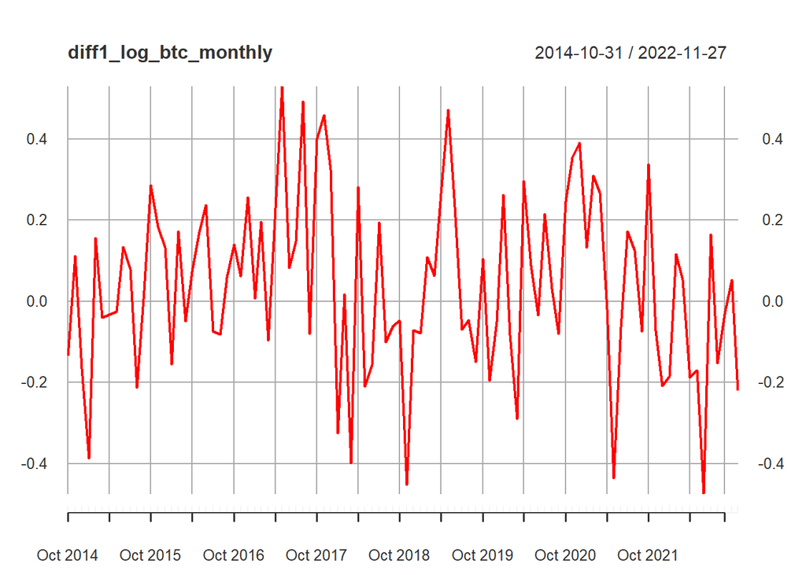

```r
diff1_log_btc_monthly <- diff(log_btc_monthly, differences=1) # same as btc_logrtn_monthly
diff1_log_btc_monthly <- na.omit(diff1_log_btc_monthly)
plot(diff1_log_btc_monthly, col = "red")
```

```r
#plot(btc_logrtn_monthly, col = "red")

# test non-stationary
adf.test(diff1_log_btc_monthly)
```

```
##
##  Augmented Dickey-Fuller Test
##
## data:  diff1_log_btc_monthly
## Dickey-Fuller = -3.9411, Lag order = 4, p-value = 0.01507
## alternative hypothesis: stationary
```

```r
# test white noise
Box.test(diff1_log_btc_monthly, lag=60, type="Ljung")
```

```
##
##  Box-Ljung test
##
## data:  diff1_log_btc_monthly
## X-squared = 83.962, df = 60, p-value = 0.02229
```

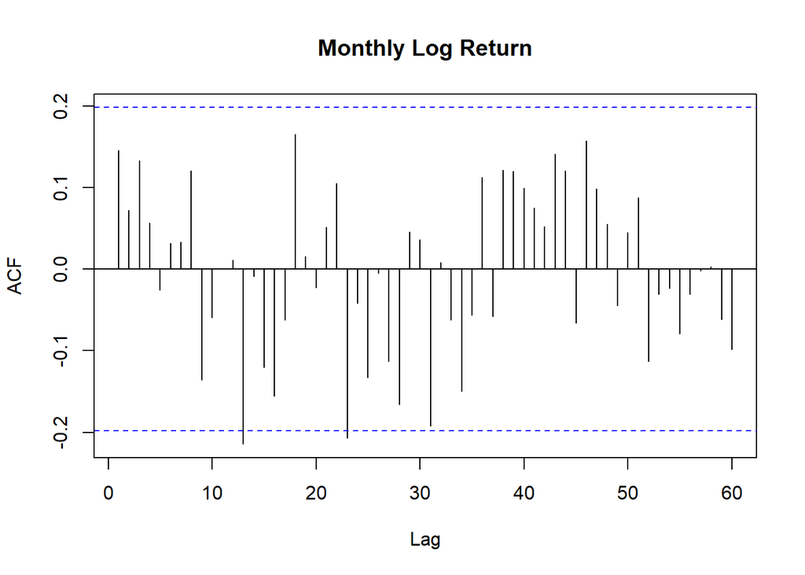

```r
acf(ts(diff1_log_btc_monthly), main='Monthly Log Return', lag=60)
```

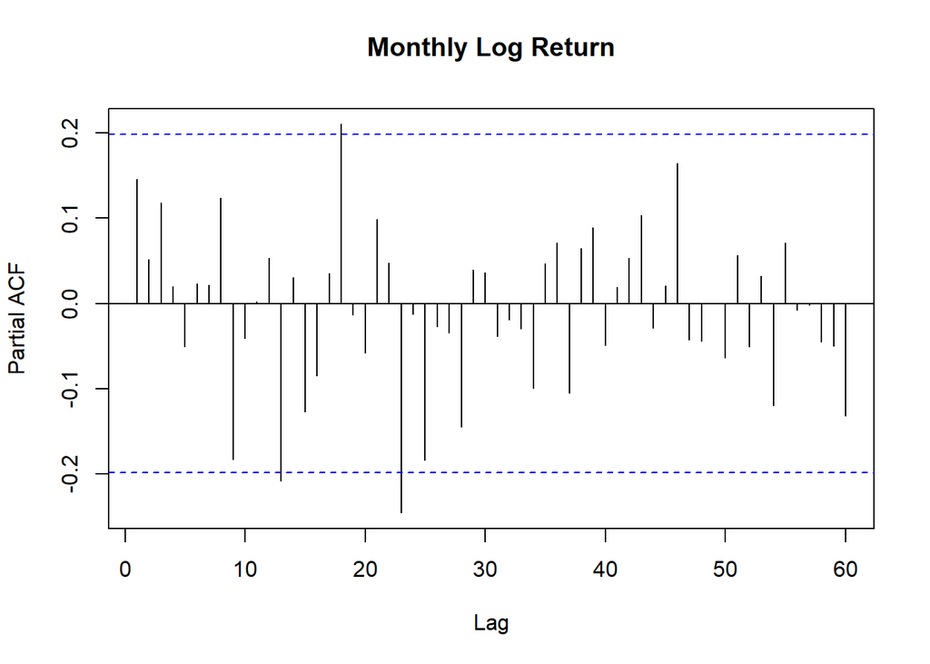

```r
pacf(ts(diff1_log_btc_monthly),main='Monthly Log Return', lag=60)
```

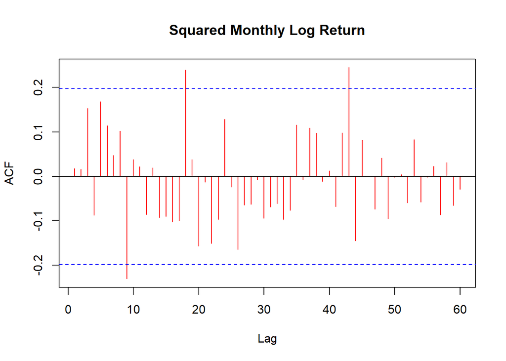

```r
# test arch effect
acf(ts(diff1_log_btc_monthly^2),60, col="red", main='Squared Monthly Log Return')
```

```r
Box.test(diff1_log_btc_monthly^2,lag=60,type="Ljung")
```

```
##
##  Box-Ljung test
##
## data:  diff1_log_btc_monthly^2
## X-squared = 80.003, df = 60, p-value = 0.04321
```

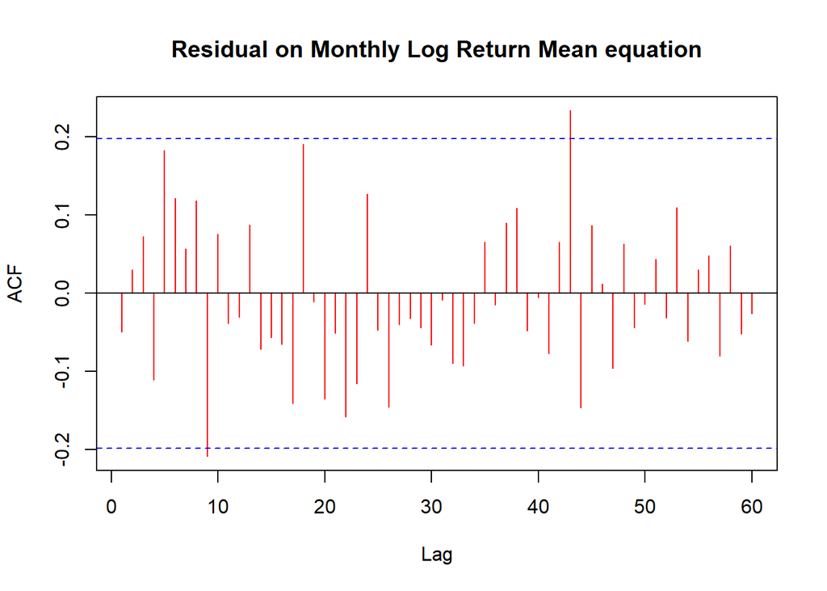

```r
atMonthly=diff1_log_btc_monthly-mean(diff1_log_btc_monthly)
acf(ts(atMonthly^2),60,col="red", main='Residual on Monthly Log Return Mean equation')
```

```r
Box.test(atMonthly^2,lag=60,type="Ljung")
```

```
##
##  Box-Ljung test
##
## data:  atMonthly^2
## X-squared = 73.249, df = 60, p-value = 0.117
```

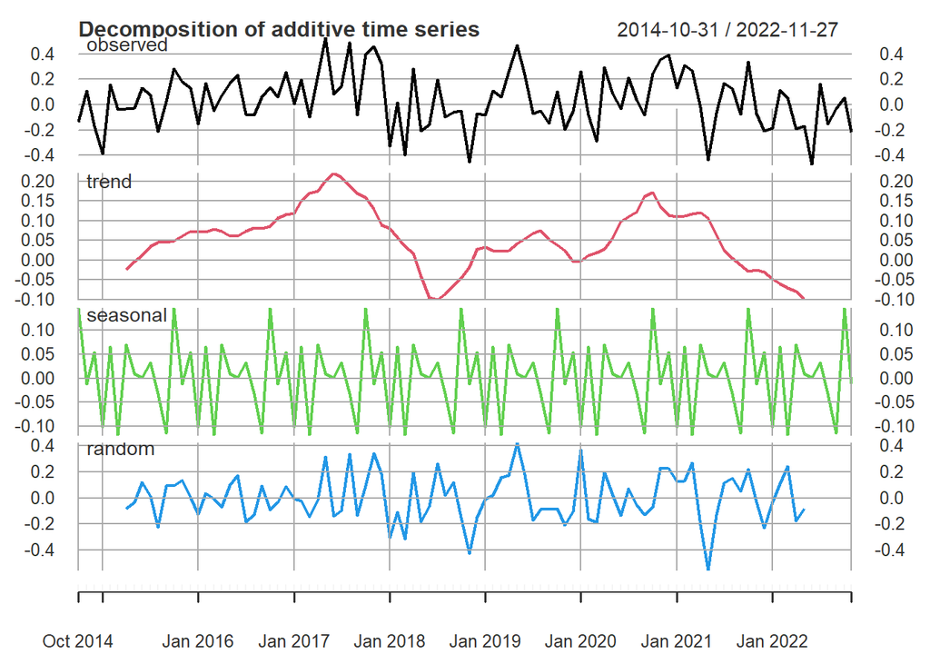

```r
dex <- decompose.xts(diff1_log_btc_monthly)
plot(dex)
```

monthly log return series: stationary + serial correlations. squared series not white noise, indicating presence of ARCH effect

## Modelling

Train Test Split for Model Evaluation, later we will do 5-step ahead prediction

```r
h=5 # The forecasting horizon.

trainRow_Daily=nrow(diff1_log_btc_daily)-h
train_dailyR <- diff1_log_btc_daily[1:trainRow_Daily,]
test_dailyR <- diff1_log_btc_daily[-c(1:trainRow_Daily),]

# tail(train_dailyR)
# test_dailyR

trainRow_Weekly=nrow(diff1_log_btc_weekly)-h
train_weeklyR <- diff1_log_btc_weekly[1:trainRow_Weekly,]
test_weeklyR <- diff1_log_btc_weekly[-c(1:trainRow_Weekly),]

# tail(train_weeklyR)
# test_weeklyR

trainRow_Monthly=nrow(diff1_log_btc_monthly)-h
train_monthlyR <- diff1_log_btc_monthly[1:trainRow_Monthly,]
test_monthlyR <- diff1_log_btc_monthly[-c(1:trainRow_Monthly),]

# tail(train_monthlyR)
# test_monthlyR
```

### Daily

look for mean model if applicable

```r
mm_daily <- auto.arima(log_btc_daily)
mm_daily
```

```
## Series: log_btc_daily
## ARIMA(0,1,0)(1,0,1)[7] with drift
##
## Coefficients:
##         sar1     sma1   drift
##       0.3683  -0.3955  0.0012
## s.e.  0.6955   0.6892  0.0007
##
## sigma^2 = 0.001509:  log likelihood = 5476.68
## AIC=-10945.36   AICc=-10945.34   BIC=-10921.34
```

coefficient insignificant, no mean model, look for volatility model

trying diff distribution model of residual with SGARCH, nig followed by std yet none of them are adequate for daily return

```r
spec1=ugarchspec(variance.model=list(model="sGARCH",  garchOrder = c(1,1)),
                 mean.model=list(armaOrder=c(0,0),include.mean = TRUE),
                 distribution.model='norm')

mD1=ugarchfit(spec=spec1,data=train_dailyR)
show(mD1)
```

```
##
## *---------------------------------*
## *          GARCH Model Fit        *
## *---------------------------------*
##
## Conditional Variance Dynamics
## -----------------------------------
## GARCH Model  : sGARCH(1,1)
## Mean Model   : ARFIMA(0,0,0)
## Distribution : norm
##
## Optimal Parameters
## ------------------------------------
##         Estimate  Std. Error  t value Pr(>|t|)
## mu      0.001670    0.000596   2.8017 0.005084
## omega   0.000078    0.000012   6.6346 0.000000
## alpha1  0.128709    0.014468   8.8963 0.000000
## beta1   0.832808    0.016047  51.8968 0.000000
##
## Robust Standard Errors:
##         Estimate  Std. Error  t value Pr(>|t|)
## mu      0.001670    0.000666   2.5086 0.012120
## omega   0.000078    0.000028   2.7735 0.005546
## alpha1  0.128709    0.033363   3.8578 0.000114
## beta1   0.832808    0.028955  28.7618 0.000000
##
## LogLikelihood : 5688.625
##
## Information Criteria
## ------------------------------------
##
## Akaike       -3.8050
## Bayes        -3.7969
## Shibata      -3.8050
## Hannan-Quinn -3.8021
##
## Weighted Ljung-Box Test on Standardized Residuals
## ------------------------------------
##                         statistic p-value
## Lag[1]                      5.116 0.02371
```

[output cut: 37 more lines]

```
## Negative Sign Bias  0.2467 0.8052
## Positive Sign Bias  0.5848 0.5587
## Joint Effect        2.2459 0.5230
##
##
## Adjusted Pearson Goodness-of-Fit Test:
## ------------------------------------
##   group statistic p-value(g-1)
## 1    20     443.5    3.738e-82
## 2    30     475.6    2.956e-82
## 3    40     490.4    2.065e-79
## 4    50     522.9    1.587e-80
##
##
## Elapsed time : 0.349066
```

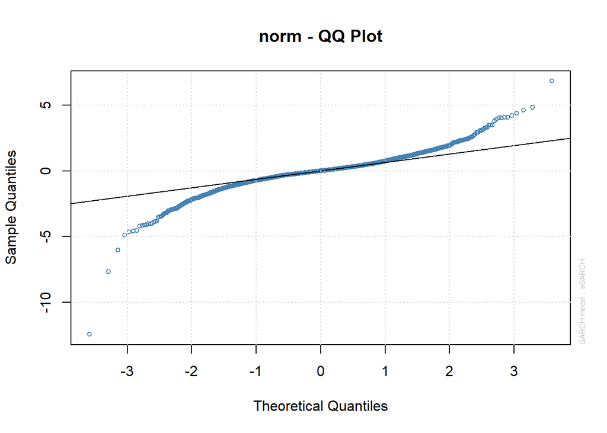

```r
plot(mD1, which=9)
```

```r
res_mD1=residuals(mD1)
Box.test(res_mD1,10,type="Ljung")
```

```
##
##  Box-Ljung test
##
## data:  res_mD1
## X-squared = 18.197, df = 10, p-value = 0.05173
```

```r
Box.test(res_mD1^2,10,type="Ljung")
```

```
##
##  Box-Ljung test
##
## data:  res_mD1^2
## X-squared = 112.75, df = 10, p-value < 2.2e-16
```

```r
spec2=ugarchspec(variance.model=list(model="sGARCH",  garchOrder = c(1,1)),
                 mean.model=list(armaOrder=c(0,0),include.mean = TRUE),
                 distribution.model='std')

mD2=ugarchfit(spec=spec2,data=train_dailyR)
mD2
```

```
##
## *---------------------------------*
## *          GARCH Model Fit        *
## *---------------------------------*
##
## Conditional Variance Dynamics
## -----------------------------------
## GARCH Model  : sGARCH(1,1)
## Mean Model   : ARFIMA(0,0,0)
## Distribution : std
##
## Optimal Parameters
## ------------------------------------
##         Estimate  Std. Error  t value Pr(>|t|)
## mu      0.001498    0.000397   3.7776 0.000158
## omega   0.000016    0.000006   2.9107 0.003606
## alpha1  0.107699    0.012272   8.7759 0.000000
## beta1   0.891301    0.013567  65.6960 0.000000
## shape   3.271933    0.164358  19.9073 0.000000
##
## Robust Standard Errors:
##         Estimate  Std. Error  t value Pr(>|t|)
## mu      0.001498    0.000399   3.7560 0.000173
## omega   0.000016    0.000010   1.6068 0.108109
## alpha1  0.107699    0.013691   7.8662 0.000000
## beta1   0.891301    0.021187  42.0693 0.000000
## shape   3.271933    0.191374  17.0971 0.000000
##
## LogLikelihood : 6109.914
##
## Information Criteria
## ------------------------------------
##
## Akaike       -4.0863
## Bayes        -4.0762
## Shibata      -4.0863
## Hannan-Quinn -4.0827
##
## Weighted Ljung-Box Test on Standardized Residuals
## ------------------------------------
```

[output cut: 40 more lines]

```
## Negative Sign Bias  0.4529 0.6507
## Positive Sign Bias  0.7935 0.4275
## Joint Effect        1.8788 0.5979
##
##
## Adjusted Pearson Goodness-of-Fit Test:
## ------------------------------------
##   group statistic p-value(g-1)
## 1    20     44.22    0.0008797
## 2    30     55.39    0.0022283
## 3    40     67.90    0.0028085
## 4    50     74.52    0.0108516
##
##
## Elapsed time : 0.4827089
```

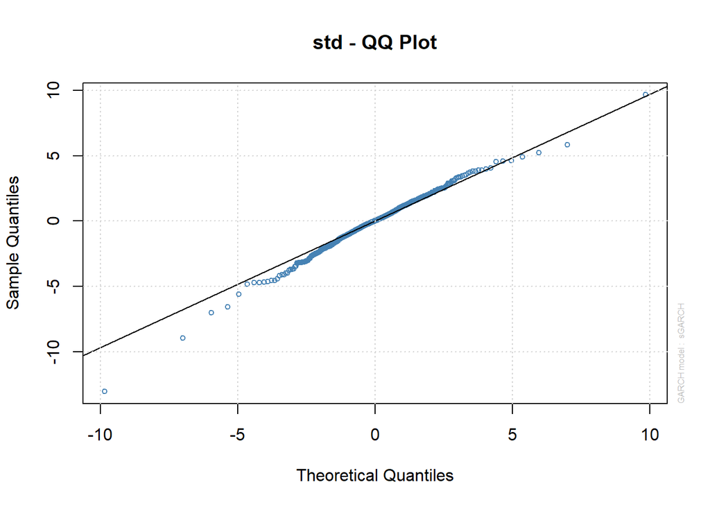

```r
plot(mD2, which=9)
```

```r
res_mD2=residuals(mD2)
Box.test(res_mD2,10,type="Ljung")
```

```
##
##  Box-Ljung test
##
## data:  res_mD2
## X-squared = 18.197, df = 10, p-value = 0.05173
```

```r
Box.test(res_mD2^2,10,type="Ljung")
```

```
##
##  Box-Ljung test
##
## data:  res_mD2^2
## X-squared = 112.96, df = 10, p-value < 2.2e-16
```

```r
spec3=ugarchspec(variance.model=list(model="sGARCH",  garchOrder = c(1,1)),
                 mean.model=list(armaOrder=c(0,0),include.mean = TRUE),
                 distribution.model='ged'
                 )

mD3=ugarchfit(spec=spec3,data=train_dailyR)
mD3
```

```
##
## *---------------------------------*
## *          GARCH Model Fit        *
## *---------------------------------*
##
## Conditional Variance Dynamics
## -----------------------------------
## GARCH Model  : sGARCH(1,1)
## Mean Model   : ARFIMA(0,0,0)
## Distribution : ged
##
## Optimal Parameters
## ------------------------------------
##         Estimate  Std. Error  t value Pr(>|t|)
## mu      0.001676    0.000224   7.4945 0.000000
## omega   0.000022    0.000007   3.0311 0.002437
## alpha1  0.120787    0.017969   6.7219 0.000000
## beta1   0.878205    0.016556  53.0442 0.000000
## shape   0.884208    0.026953  32.8054 0.000000
##
## Robust Standard Errors:
##         Estimate  Std. Error  t value Pr(>|t|)
## mu      0.001676    0.000159  10.5129 0.000000
## omega   0.000022    0.000012   1.8263 0.067798
## alpha1  0.120787    0.021766   5.5493 0.000000
## beta1   0.878205    0.022184  39.5878 0.000000
## shape   0.884208    0.037013  23.8894 0.000000
##
## LogLikelihood : 6109.243
##
## Information Criteria
## ------------------------------------
##
## Akaike       -4.0858
## Bayes        -4.0758
## Shibata      -4.0858
## Hannan-Quinn -4.0822
##
## Weighted Ljung-Box Test on Standardized Residuals
## ------------------------------------
```

[output cut: 40 more lines]

```
## Negative Sign Bias  0.5812 0.5612
## Positive Sign Bias  0.8666 0.3862
## Joint Effect        2.2724 0.5178
##
##
## Adjusted Pearson Goodness-of-Fit Test:
## ------------------------------------
##   group statistic p-value(g-1)
## 1    20     28.49       0.0744
## 2    30     38.83       0.1050
## 3    40     45.12       0.2314
## 4    50     49.48       0.4538
##
##
## Elapsed time : 0.846736
```

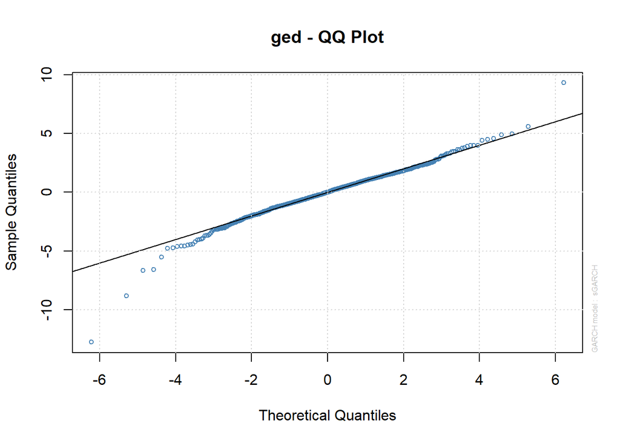

```r
plot(mD3, which=9)
```

```r
res_mD3=residuals(mD3)
Box.test(res_mD3,10,type="Ljung")
```

```
##
##  Box-Ljung test
##
## data:  res_mD3
## X-squared = 18.197, df = 10, p-value = 0.05173
```

```r
Box.test(res_mD3^2,10,type="Ljung")
```

```
##
##  Box-Ljung test
##
## data:  res_mD3^2
## X-squared = 112.74, df = 10, p-value < 2.2e-16
```

```r
spec4=ugarchspec(variance.model=list(model="sGARCH",  garchOrder = c(1,1)),
                 mean.model=list(armaOrder=c(0,0),include.mean = TRUE),
                 distribution.model='nig'
                 )

mD4=ugarchfit(spec=spec4,data=train_dailyR)
mD4
```

```
##
## *---------------------------------*
## *          GARCH Model Fit        *
## *---------------------------------*
##
## Conditional Variance Dynamics
## -----------------------------------
## GARCH Model  : sGARCH(1,1)
## Mean Model   : ARFIMA(0,0,0)
## Distribution : nig
##
## Optimal Parameters
## ------------------------------------
##         Estimate  Std. Error  t value Pr(>|t|)
## mu      0.000905    0.000494   1.8336 0.066719
## omega   0.000019    0.000007   2.7017 0.006898
## alpha1  0.115106    0.015284   7.5313 0.000000
## beta1   0.883894    0.015514  56.9753 0.000000
## skew   -0.067197    0.036736  -1.8292 0.067372
## shape   0.437858    0.045791   9.5622 0.000000
##
## Robust Standard Errors:
##         Estimate  Std. Error  t value Pr(>|t|)
## mu      0.000905    0.000551   1.6416 0.100667
## omega   0.000019    0.000013   1.4451 0.148416
## alpha1  0.115106    0.018014   6.3898 0.000000
## beta1   0.883894    0.023142  38.1945 0.000000
## skew   -0.067197    0.039088  -1.7191 0.085592
## shape   0.437858    0.058476   7.4878 0.000000
##
## LogLikelihood : 6122.261
##
## Information Criteria
## ------------------------------------
##
## Akaike       -4.0939
## Bayes        -4.0818
## Shibata      -4.0939
## Hannan-Quinn -4.0895
##
```

[output cut: 43 more lines]

```
## Negative Sign Bias  0.5469 0.5845
## Positive Sign Bias  0.8928 0.3720
## Joint Effect        2.2307 0.5259
##
##
## Adjusted Pearson Goodness-of-Fit Test:
## ------------------------------------
##   group statistic p-value(g-1)
## 1    20     20.85       0.3452
## 2    30     31.60       0.3378
## 3    40     43.97       0.2693
## 4    50     51.42       0.3790
##
##
## Elapsed time : 1.492012
```

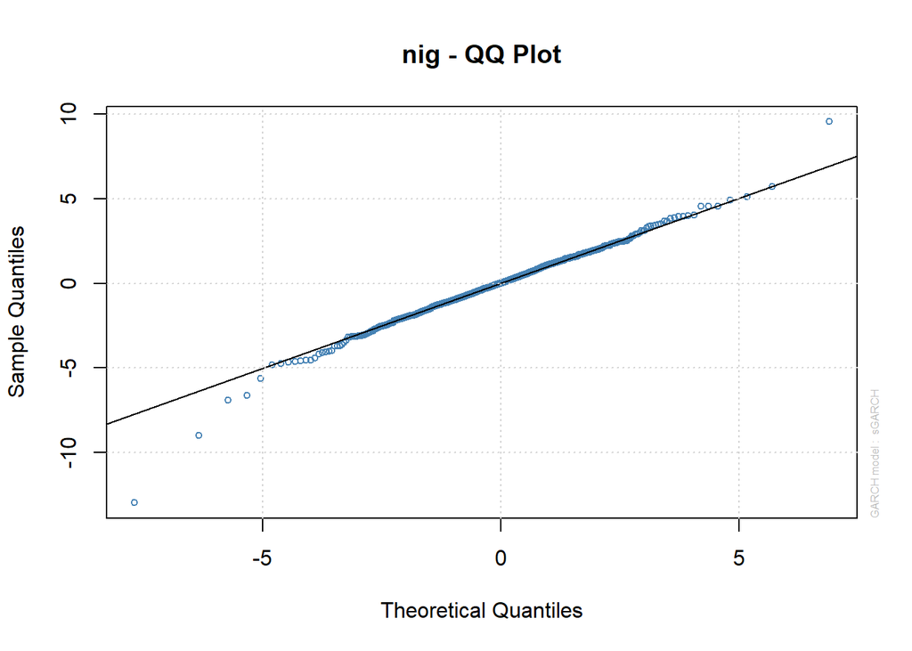

```r
plot(mD4, which=9)
```

```r
res_mD4=residuals(mD4)
Box.test(res_mD4,10,type="Ljung")
```

```
##
##  Box-Ljung test
##
## data:  res_mD4
## X-squared = 18.197, df = 10, p-value = 0.05173
```

```r
Box.test(res_mD4^2,10,type="Ljung")
```

```
##
##  Box-Ljung test
##
## data:  res_mD4^2
## X-squared = 113.68, df = 10, p-value < 2.2e-16
```

```r
mod1 <- garchFit(train_dailyR~1+garch(1,1), data=train_dailyR)
```

[output not shown]

[output cut: 28 more lines]

[output not shown]

```r
summary(mod1)
```

```
##
## Title:
##  GARCH Modelling
##
## Call:
##  garchFit(formula = train_dailyR ~ 1 + garch(1, 1), data = train_dailyR)
##
## Mean and Variance Equation:
##  data ~ 1 + garch(1, 1)
## <environment: 0x000000002c086d50>
##  [data = train_dailyR]
##
## Conditional Distribution:
##  norm
##
## Coefficient(s):
##         mu       omega      alpha1       beta1
## 1.6700e-03  7.7547e-05  1.2883e-01  8.3272e-01
##
## Std. Errors:
##  based on Hessian
##
## Error Analysis:
##         Estimate  Std. Error  t value Pr(>|t|)
## mu     1.670e-03   5.959e-04    2.802  0.00507 **
## omega  7.755e-05   1.166e-05    6.653 2.88e-11 ***
## alpha1 1.288e-01   1.447e-02    8.906  < 2e-16 ***
## beta1  8.327e-01   1.602e-02   51.994  < 2e-16 ***
## ---
## Signif. codes:  0 '***' 0.001 '**' 0.01 '*' 0.05 '.' 0.1 ' ' 1
##
## Log Likelihood:
##  5688.646    normalized:  1.903831
##
## Description:
##  Mon Nov 28 23:48:32 2022 by user: karin
##
##
## Standardised Residuals Tests:
##                                 Statistic p-Value
##  Jarque-Bera Test   R    Chi^2  20432.15  0
##  Shapiro-Wilk Test  R    W      0.9061287 0
##  Ljung-Box Test     R    Q(10)  25.54336  0.004405395
##  Ljung-Box Test     R    Q(15)  27.65554  0.02382746
##  Ljung-Box Test     R    Q(20)  32.4319   0.03890808
##  Ljung-Box Test     R^2  Q(10)  3.926541  0.9506
##  Ljung-Box Test     R^2  Q(15)  4.646525  0.9947197
##  Ljung-Box Test     R^2  Q(20)  6.042044  0.9988395
##  LM Arch Test       R    TR^2   4.139254  0.9807904
##
## Information Criterion Statistics:
##       AIC       BIC       SIC      HQIC
## -3.804984 -3.796949 -3.804987 -3.802093
```

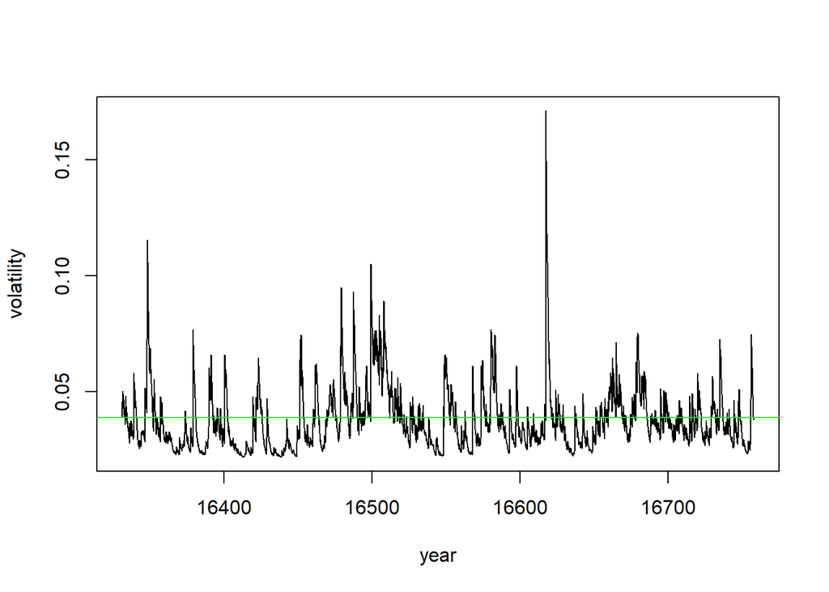

```r
vola <- fGarch::volatility(mod1)
plot(ts(vola, start=start(train_dailyR), frequency=frequency(train_dailyR)),
     xlab="year", ylab="volatility")
abline(h=sd(train_dailyR), col="green")
```

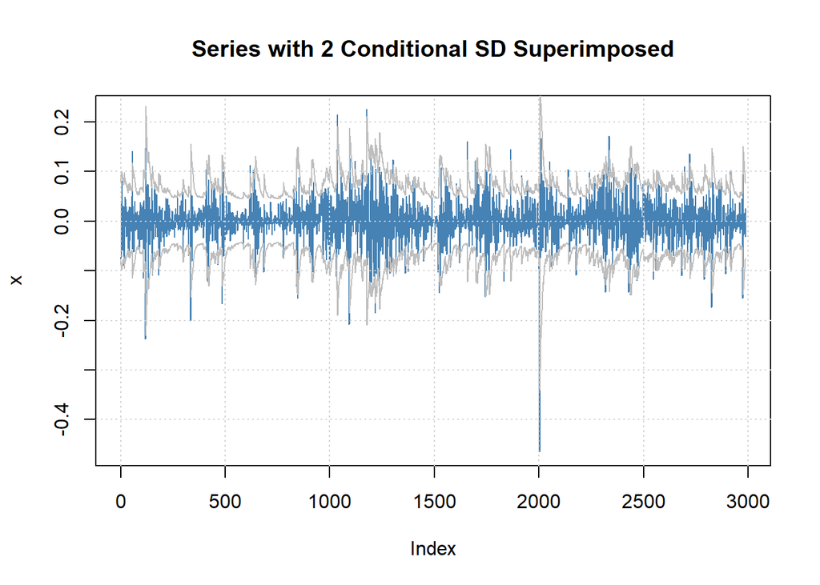

```r
plot(mod1, which=3)
```

```r
#garch - t
mod2 <- garchFit(~ 1 + garch(1,1), data=train_dailyR,
                 cond.dist="std", trace=FALSE)
summary(mod2)
```

```
##
## Title:
##  GARCH Modelling
##
## Call:
##  garchFit(formula = ~1 + garch(1, 1), data = train_dailyR, cond.dist = "std",
##     trace = FALSE)
##
## Mean and Variance Equation:
##  data ~ 1 + garch(1, 1)
## <environment: 0x000000003023ba40>
##  [data = train_dailyR]
##
## Conditional Distribution:
##  std
##
## Coefficient(s):
##        mu      omega     alpha1      beta1      shape
## 0.0014498  0.0000105  0.1795511  0.8913058  2.6589304
##
## Std. Errors:
##  based on Hessian
##
## Error Analysis:
##         Estimate  Std. Error  t value Pr(>|t|)
## mu     1.450e-03   3.748e-04    3.868  0.00011 ***
## omega  1.050e-05   5.644e-06    1.860  0.06284 .
## alpha1 1.796e-01   3.595e-02    4.995 5.89e-07 ***
## beta1  8.913e-01   1.277e-02   69.780  < 2e-16 ***
## shape  2.659e+00   1.545e-01   17.208  < 2e-16 ***
## ---
## Signif. codes:  0 '***' 0.001 '**' 0.01 '*' 0.05 '.' 0.1 ' ' 1
##
## Log Likelihood:
##  6119.695    normalized:  2.048091
##
## Description:
##  Mon Nov 28 23:48:33 2022 by user: karin
##
##
## Standardised Residuals Tests:
##                                 Statistic p-Value
##  Jarque-Bera Test   R    Chi^2  36669.8   0
##  Shapiro-Wilk Test  R    W      0.8742122 0
##  Ljung-Box Test     R    Q(10)  35.08393  0.0001208132
##  Ljung-Box Test     R    Q(15)  38.03785  0.0008907447
##  Ljung-Box Test     R    Q(20)  44.1545   0.001434854
##  Ljung-Box Test     R^2  Q(10)  3.267051  0.9744227
##  Ljung-Box Test     R^2  Q(15)  4.889994  0.9930175
##  Ljung-Box Test     R^2  Q(20)  7.893057  0.9925519
##  LM Arch Test       R    TR^2   4.054326  0.982436
##
## Information Criterion Statistics:
##       AIC       BIC       SIC      HQIC
## -4.092835 -4.082791 -4.092841 -4.089221
```

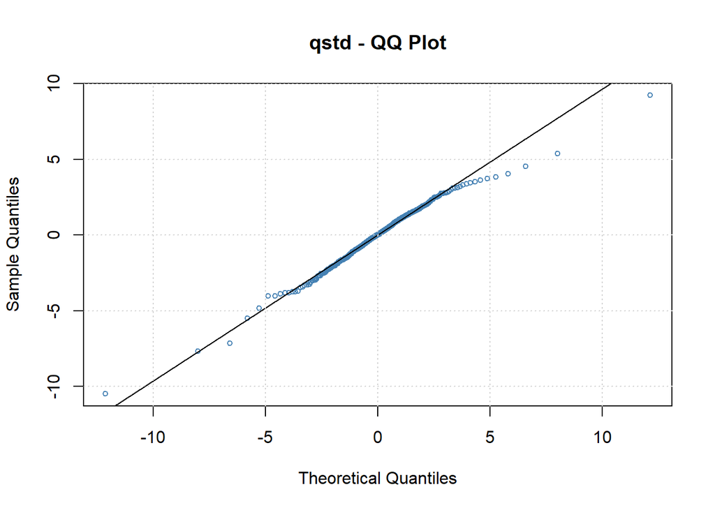

```r
plot(mod2, which=13)
```

```r
mod3 <- garchFit(~ 1 + garch(1,1), data=train_dailyR,
                 cond.dist="sstd", trace=FALSE)
summary(mod3)
```

```
##
## Title:
##  GARCH Modelling
##
## Call:
##  garchFit(formula = ~1 + garch(1, 1), data = train_dailyR, cond.dist = "sstd",
##     trace = FALSE)
##
## Mean and Variance Equation:
##  data ~ 1 + garch(1, 1)
## <environment: 0x000000002bd0acd0>
##  [data = train_dailyR]
##
## Conditional Distribution:
##  sstd
##
## Coefficient(s):
##         mu       omega      alpha1       beta1        skew       shape
## 0.00109318  0.00001083  0.18131073  0.89053581  0.97570467  2.65733215
##
## Std. Errors:
##  based on Hessian
##
## Error Analysis:
##         Estimate  Std. Error  t value Pr(>|t|)
## mu     1.093e-03   4.893e-04    2.234   0.0255 *
## omega  1.083e-05   5.729e-06    1.890   0.0587 .
## alpha1 1.813e-01   3.651e-02    4.966 6.84e-07 ***
## beta1  8.905e-01   1.287e-02   69.218  < 2e-16 ***
## skew   9.757e-01   2.116e-02   46.118  < 2e-16 ***
## shape  2.657e+00   1.549e-01   17.152  < 2e-16 ***
## ---
## Signif. codes:  0 '***' 0.001 '**' 0.01 '*' 0.05 '.' 0.1 ' ' 1
##
## Log Likelihood:
##  6120.34    normalized:  2.048307
##
## Description:
##  Mon Nov 28 23:48:34 2022 by user: karin
##
##
## Standardised Residuals Tests:
##                                 Statistic p-Value
##  Jarque-Bera Test   R    Chi^2  36883.33  0
##  Shapiro-Wilk Test  R    W      0.8740782 0
##  Ljung-Box Test     R    Q(10)  35.29296  0.0001112745
##  Ljung-Box Test     R    Q(15)  38.28257  0.0008194568
##  Ljung-Box Test     R    Q(20)  44.47852  0.00129791
##  Ljung-Box Test     R^2  Q(10)  3.300427  0.9734444
##  Ljung-Box Test     R^2  Q(15)  4.928612  0.9927138
##  Ljung-Box Test     R^2  Q(20)  7.931082  0.992314
##  LM Arch Test       R    TR^2   4.100265  0.9815584
##
## Information Criterion Statistics:
##       AIC       BIC       SIC      HQIC
## -4.092597 -4.080544 -4.092605 -4.088261
```

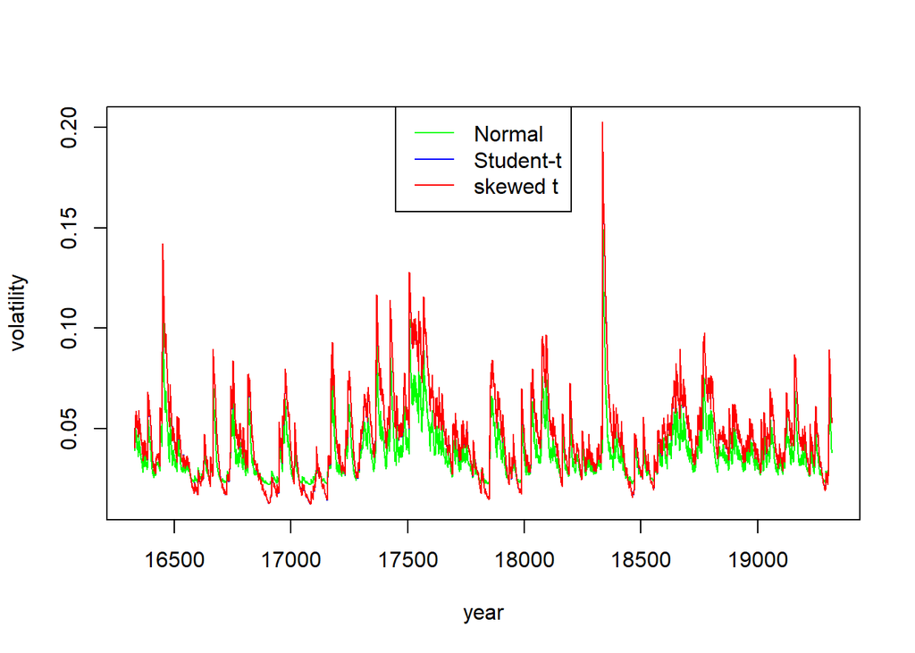

```r
x.btc <- as.vector(time(train_dailyR))
vola1 <- fGarch::volatility(mod1)
vola2 <- fGarch::volatility(mod2)
vola3 <- fGarch::volatility(mod3)
matplot(x.btc, cbind(vola1, vola2, vola3),
        type="l",
        lty=1, col=c("green", "blue", "red"),
        xlab="year", ylab="volatility")
legend('top', lty=1, col=c("green", "blue", "red"),
       legend=c("Normal", "Student-t", "skewed t"))
```

```r
library(tibble)
p1 <- predict(mod1, n.ahead=h)[["standardDeviation"]]
p2 <- predict(mod2, n.ahead=h)[["standardDeviation"]]
p3 <- predict(mod3, n.ahead=h)[["standardDeviation"]]
pred.tab <- tibble(
  "n-head"=1:h,
  "normal"=p1,
  "student-t"=p2,
  "skewed t"=p3
)
knitr::kable(pred.tab, digits=4)
```

| n-head | normal | student-t | skewed t |
| --- | --- | --- | --- |
| 1 | 0.0368 | 0.0510 | 0.0509 |
| 2 | 0.0372 | 0.0529 | 0.0528 |
| 3 | 0.0375 | 0.0548 | 0.0548 |
| 4 | 0.0378 | 0.0568 | 0.0568 |
| 5 | 0.0381 | 0.0589 | 0.0589 |

Tried eGARCH / iGARCH / gjrGARCH - all not adequate on daily return neither…

```r
spec1=ugarchspec(variance.model=list(model="eGARCH",  garchOrder = c(1,1)),
                 mean.model=list(armaOrder=c(0,0),include.mean = TRUE) )

mD1=ugarchfit(spec=spec1,data=train_dailyR)
show(mD1)
```

```
##
## *---------------------------------*
## *          GARCH Model Fit        *
## *---------------------------------*
##
## Conditional Variance Dynamics
## -----------------------------------
## GARCH Model  : eGARCH(1,1)
## Mean Model   : ARFIMA(0,0,0)
## Distribution : norm
##
## Optimal Parameters
## ------------------------------------
##         Estimate  Std. Error  t value Pr(>|t|)
## mu      0.001291    0.000276   4.6789  3.0e-06
## omega  -0.455628    0.066224  -6.8801  0.0e+00
## alpha1 -0.045656    0.011494  -3.9720  7.1e-05
## beta1   0.926680    0.010167  91.1463  0.0e+00
## gamma1  0.250370    0.023090  10.8431  0.0e+00
##
## Robust Standard Errors:
##         Estimate  Std. Error  t value Pr(>|t|)
## mu      0.001291    0.000141   9.1567 0.000000
## omega  -0.455628    0.140098  -3.2522 0.001145
## alpha1 -0.045656    0.031654  -1.4423 0.149212
## beta1   0.926680    0.021656  42.7903 0.000000
## gamma1  0.250370    0.041487   6.0349 0.000000
##
## LogLikelihood : 5707.272
##
## Information Criteria
## ------------------------------------
##
## Akaike       -3.8168
## Bayes        -3.8067
## Shibata      -3.8168
## Hannan-Quinn -3.8132
##
## Weighted Ljung-Box Test on Standardized Residuals
## ------------------------------------
```

[output cut: 40 more lines]

```
## Negative Sign Bias  0.2692 0.7878
## Positive Sign Bias  0.2197 0.8261
## Joint Effect        0.4745 0.9244
##
##
## Adjusted Pearson Goodness-of-Fit Test:
## ------------------------------------
##   group statistic p-value(g-1)
## 1    20     435.1    2.128e-80
## 2    30     459.2    6.733e-79
## 3    40     486.9    1.045e-78
## 4    50     488.1    1.145e-73
##
##
## Elapsed time : 0.2712739
```

```
##
## please wait...calculating quantiles...
```

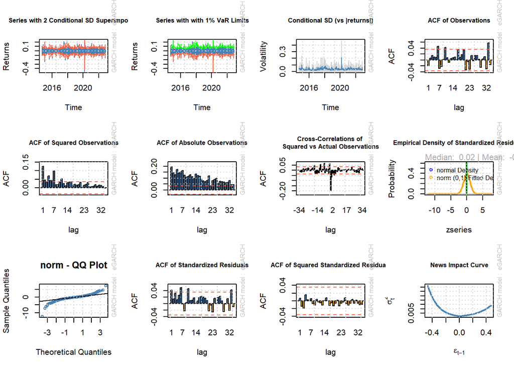

```r
plot(mD1, which='all')
```

```r
res_mD1=residuals(mD1,standardize=T)
Box.test(res_mD1,10,type="Ljung")
```

```
##
##  Box-Ljung test
##
## data:  res_mD1
## X-squared = 26.837, df = 10, p-value = 0.002763
```

```r
Box.test(res_mD1^2,10,type="Ljung")
```

```
##
##  Box-Ljung test
##
## data:  res_mD1^2
## X-squared = 3.1812, df = 10, p-value = 0.9768
```

```r
spec2=ugarchspec(variance.model=list(model="iGARCH",  garchOrder = c(1,1)),
                 mean.model=list(armaOrder=c(0,0),include.mean = TRUE) )

mD2=ugarchfit(spec=spec2,data=train_dailyR)
mD2
```

```
##
## *---------------------------------*
## *          GARCH Model Fit        *
## *---------------------------------*
##
## Conditional Variance Dynamics
## -----------------------------------
## GARCH Model  : iGARCH(1,1)
## Mean Model   : ARFIMA(0,0,0)
## Distribution : norm
##
## Optimal Parameters
## ------------------------------------
##         Estimate  Std. Error  t value Pr(>|t|)
## mu      0.001687    0.000583   2.8918  0.00383
## omega   0.000057    0.000008   7.0454  0.00000
## alpha1  0.166218    0.015340  10.8352  0.00000
## beta1   0.833782          NA       NA       NA
##
## Robust Standard Errors:
##         Estimate  Std. Error  t value Pr(>|t|)
## mu      0.001687    0.000638   2.6444 0.008184
## omega   0.000057    0.000020   2.7878 0.005307
## alpha1  0.166218    0.030003   5.5400 0.000000
## beta1   0.833782          NA       NA       NA
##
## LogLikelihood : 5679.486
##
## Information Criteria
## ------------------------------------
##
## Akaike       -3.7995
## Bayes        -3.7935
## Shibata      -3.7995
## Hannan-Quinn -3.7974
##
## Weighted Ljung-Box Test on Standardized Residuals
## ------------------------------------
##                         statistic p-value
## Lag[1]                      6.512 0.01072
```

[output cut: 36 more lines]

```
## Negative Sign Bias  0.7398 0.4595
## Positive Sign Bias  0.9625 0.3359
## Joint Effect        3.0895 0.3780
##
##
## Adjusted Pearson Goodness-of-Fit Test:
## ------------------------------------
##   group statistic p-value(g-1)
## 1    20     501.0    3.409e-94
## 2    30     517.0    9.267e-91
## 3    40     543.0    5.082e-90
## 4    50     555.6    5.293e-87
##
##
## Elapsed time : 0.1097062
```

```
##
## please wait...calculating quantiles...
```

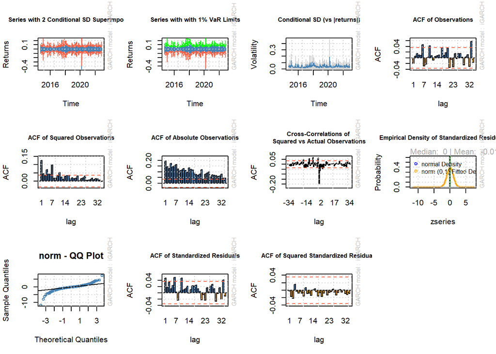

```r
plot(mD2, which='all')
```

```r
res_mD2=residuals(mD2,standardize=T)
Box.test(res_mD2,10,type="Ljung")
```

```
##
##  Box-Ljung test
##
## data:  res_mD2
## X-squared = 28.523, df = 10, p-value = 0.001488
```

```r
Box.test(res_mD2^2,10,type="Ljung")
```

```
##
##  Box-Ljung test
##
## data:  res_mD2^2
## X-squared = 4.4702, df = 10, p-value = 0.9237
```

```r
spec3=ugarchspec(variance.model=list(model="gjrGARCH",  garchOrder = c(1,1)),
                 mean.model=list(armaOrder=c(0,0),include.mean = TRUE) )

mD3=ugarchfit(spec=spec3,data=train_dailyR)
mD3
```

```
##
## *---------------------------------*
## *          GARCH Model Fit        *
## *---------------------------------*
##
## Conditional Variance Dynamics
## -----------------------------------
## GARCH Model  : gjrGARCH(1,1)
## Mean Model   : ARFIMA(0,0,0)
## Distribution : norm
##
## Optimal Parameters
## ------------------------------------
##         Estimate  Std. Error  t value Pr(>|t|)
## mu      0.001330    0.000605   2.1987 0.027897
## omega   0.000084    0.000013   6.4267 0.000000
## alpha1  0.102004    0.014458   7.0553 0.000000
## beta1   0.825152    0.017209  47.9485 0.000000
## gamma1  0.058025    0.019468   2.9805 0.002878
##
## Robust Standard Errors:
##         Estimate  Std. Error  t value Pr(>|t|)
## mu      0.001330    0.000617   2.1572 0.030987
## omega   0.000084    0.000033   2.5107 0.012049
## alpha1  0.102004    0.026339   3.8727 0.000108
## beta1   0.825152    0.034637  23.8230 0.000000
## gamma1  0.058025    0.057714   1.0054 0.314710
##
## LogLikelihood : 5693.722
##
## Information Criteria
## ------------------------------------
##
## Akaike       -3.8077
## Bayes        -3.7977
## Shibata      -3.8077
## Hannan-Quinn -3.8041
##
## Weighted Ljung-Box Test on Standardized Residuals
## ------------------------------------
```

[output cut: 40 more lines]

```
## Negative Sign Bias  0.4119 0.6804
## Positive Sign Bias  0.4376 0.6617
## Joint Effect        0.9954 0.8024
##
##
## Adjusted Pearson Goodness-of-Fit Test:
## ------------------------------------
##   group statistic p-value(g-1)
## 1    20     443.7    3.416e-82
## 2    30     470.5    3.307e-81
## 3    40     483.8    4.281e-78
## 4    50     497.8    1.417e-75
##
##
## Elapsed time : 0.4797051
```

```
##
## please wait...calculating quantiles...
```

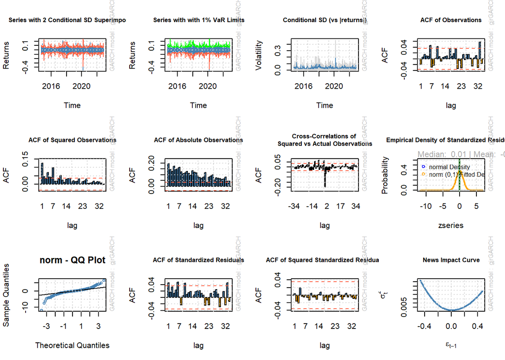

```r
plot(mD3, which='all')
```

```r
res_mD3=residuals(mD3,standardize=T)
Box.test(res_mD3,10,type="Ljung")
```

```
##
##  Box-Ljung test
##
## data:  res_mD3
## X-squared = 26.944, df = 10, p-value = 0.002658
```

```r
Box.test(res_mD3^2,10,type="Ljung")
```

```
##
##  Box-Ljung test
##
## data:  res_mD3^2
## X-squared = 4.0557, df = 10, p-value = 0.9448
```

### Weekly

look for mean model if applicable

```r
mm_weekly <- auto.arima(log_btc_weekly)
mm_weekly
```

```
## Series: log_btc_weekly
## ARIMA(0,1,0) with drift
##
## Coefficients:
##        drift
##       0.0087
## s.e.  0.0050
##
## sigma^2 = 0.0107:  log likelihood = 363.32
## AIC=-722.65   AICc=-722.62   BIC=-714.53
```

coefficient insignificant, look for volatility model

```r
mod1 <- garchFit(~ 1 + garch(1,1), data=train_weeklyR)
```

[output not shown]

[output cut: 26 more lines]

[output not shown]

```r
summary(mod1)
```

```
##
## Title:
##  GARCH Modelling
##
## Call:
##  garchFit(formula = ~1 + garch(1, 1), data = train_weeklyR)
##
## Mean and Variance Equation:
##  data ~ 1 + garch(1, 1)
## <environment: 0x000000003741da38>
##  [data = train_weeklyR]
##
## Conditional Distribution:
##  norm
##
## Coefficient(s):
##        mu      omega     alpha1      beta1
## 0.0076397  0.0020691  0.2461982  0.5701955
##
## Std. Errors:
##  based on Hessian
##
## Error Analysis:
##         Estimate  Std. Error  t value Pr(>|t|)
## mu     0.0076397   0.0045232    1.689 0.091218 .
## omega  0.0020691   0.0007075    2.925 0.003449 **
## alpha1 0.2461982   0.0745147    3.304 0.000953 ***
## beta1  0.5701955   0.1051790    5.421 5.92e-08 ***
## ---
## Signif. codes:  0 '***' 0.001 '**' 0.01 '*' 0.05 '.' 0.1 ' ' 1
##
## Log Likelihood:
##  381.5241    normalized:  0.9040857
##
## Description:
##  Mon Nov 28 23:48:39 2022 by user: karin
##
##
## Standardised Residuals Tests:
##                                 Statistic p-Value
##  Jarque-Bera Test   R    Chi^2  41.32662  1.061789e-09
##  Shapiro-Wilk Test  R    W      0.9796775 1.21294e-05
##  Ljung-Box Test     R    Q(10)  8.470256  0.5830033
##  Ljung-Box Test     R    Q(15)  9.294194  0.8616394
##  Ljung-Box Test     R    Q(20)  18.48086  0.5557636
##  Ljung-Box Test     R^2  Q(10)  4.635245  0.9141758
##  Ljung-Box Test     R^2  Q(15)  7.068313  0.9557263
##  Ljung-Box Test     R^2  Q(20)  15.45307  0.7499224
##  LM Arch Test       R    TR^2   4.804497  0.964192
##
## Information Criterion Statistics:
##       AIC       BIC       SIC      HQIC
## -1.789214 -1.750873 -1.789391 -1.774063
```

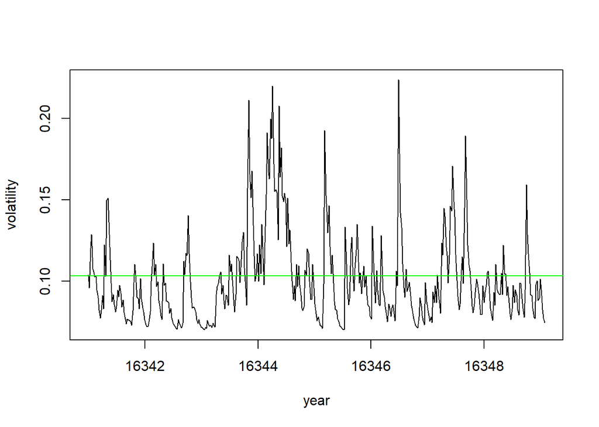

```r
vola <- fGarch::volatility(mod1)
plot(ts(vola, start=start(train_weeklyR), frequency=frequency(train_weeklyR)),
     xlab="year", ylab="volatility")
abline(h=sd(train_weeklyR), col="green")
```

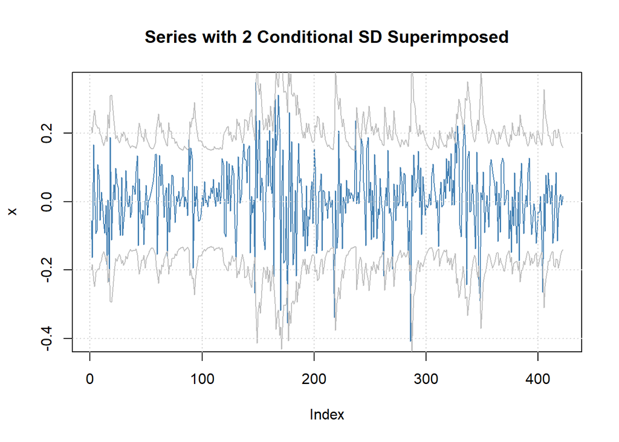

```r
plot(mod1, which=3)
```

```r
#garch - t
mod2 <- garchFit(~ 1 + garch(1,1), data=train_weeklyR,
                 cond.dist="std", trace=FALSE)
summary(mod2)
```

```
##
## Title:
##  GARCH Modelling
##
## Call:
##  garchFit(formula = ~1 + garch(1, 1), data = train_weeklyR, cond.dist = "std",
##     trace = FALSE)
##
## Mean and Variance Equation:
##  data ~ 1 + garch(1, 1)
## <environment: 0x000000002c89adc0>
##  [data = train_weeklyR]
##
## Conditional Distribution:
##  std
##
## Coefficient(s):
##        mu      omega     alpha1      beta1      shape
## 0.0086804  0.0013677  0.2554009  0.6445933  6.3094064
##
## Std. Errors:
##  based on Hessian
##
## Error Analysis:
##         Estimate  Std. Error  t value Pr(>|t|)
## mu     0.0086804   0.0041397    2.097  0.03601 *
## omega  0.0013677   0.0006689    2.045  0.04089 *
## alpha1 0.2554009   0.0935883    2.729  0.00635 **
## beta1  0.6445933   0.1092587    5.900 3.64e-09 ***
## shape  6.3094064   2.1382387    2.951  0.00317 **
## ---
## Signif. codes:  0 '***' 0.001 '**' 0.01 '*' 0.05 '.' 0.1 ' ' 1
##
## Log Likelihood:
##  388.5888    normalized:  0.9208265
##
## Description:
##  Mon Nov 28 23:48:40 2022 by user: karin
##
##
## Standardised Residuals Tests:
##                                 Statistic p-Value
##  Jarque-Bera Test   R    Chi^2  46.83383  6.763357e-11
##  Shapiro-Wilk Test  R    W      0.9787936 7.691124e-06
##  Ljung-Box Test     R    Q(10)  9.436318  0.4912553
##  Ljung-Box Test     R    Q(15)  10.15304  0.8100041
##  Ljung-Box Test     R    Q(20)  19.51516  0.4886021
##  Ljung-Box Test     R^2  Q(10)  5.714016  0.8386909
##  Ljung-Box Test     R^2  Q(15)  9.138593  0.87016
##  Ljung-Box Test     R^2  Q(20)  17.95629  0.5902877
##  LM Arch Test       R    TR^2   6.242846  0.9033486
##
## Information Criterion Statistics:
##       AIC       BIC       SIC      HQIC
## -1.817956 -1.770030 -1.818233 -1.799017
```

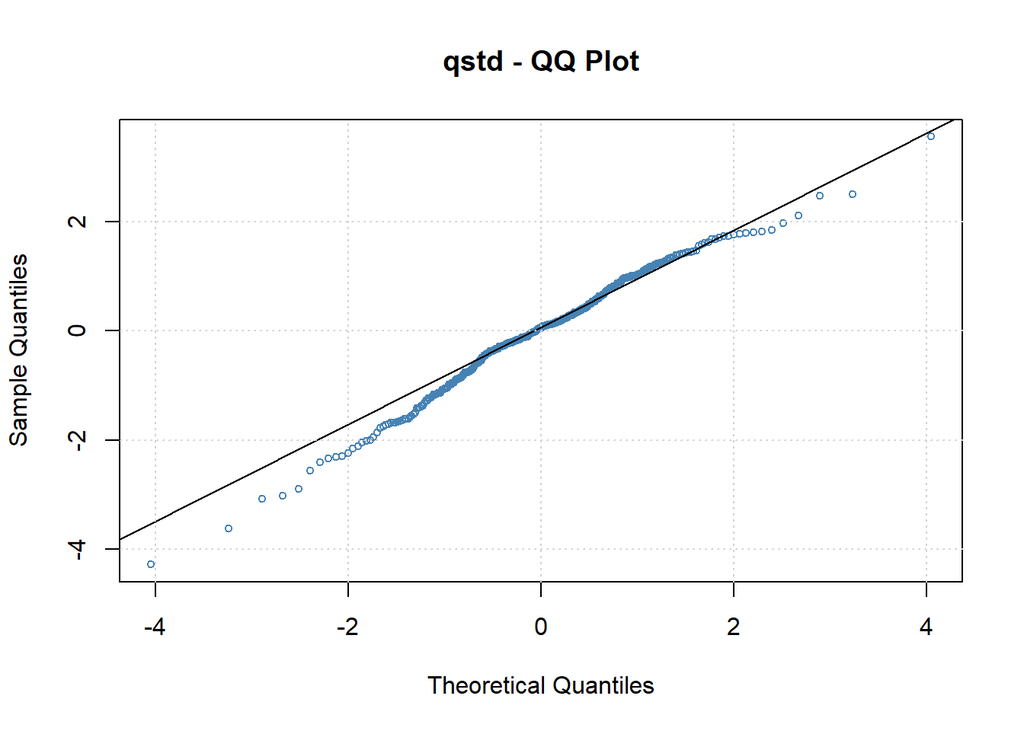

```r
plot(mod2, which=13)
```

```r
mod3 <- garchFit(~ 1 + garch(1,1), data=train_weeklyR,
                 cond.dist="sstd", trace=FALSE)
summary(mod3)
```

```
##
## Title:
##  GARCH Modelling
##
## Call:
##  garchFit(formula = ~1 + garch(1, 1), data = train_weeklyR, cond.dist = "sstd",
##     trace = FALSE)
##
## Mean and Variance Equation:
##  data ~ 1 + garch(1, 1)
## <environment: 0x000000002b426ce0>
##  [data = train_weeklyR]
##
## Conditional Distribution:
##  sstd
##
## Coefficient(s):
##        mu      omega     alpha1      beta1       skew      shape
## 0.0042836  0.0016185  0.2858881  0.5975272  0.8595089  7.0061334
##
## Std. Errors:
##  based on Hessian
##
## Error Analysis:
##         Estimate  Std. Error  t value Pr(>|t|)
## mu     0.0042836   0.0045699    0.937  0.34858
## omega  0.0016185   0.0007021    2.305  0.02116 *
## alpha1 0.2858881   0.0965692    2.960  0.00307 **
## beta1  0.5975272   0.1108566    5.390 7.04e-08 ***
## skew   0.8595089   0.0571200   15.047  < 2e-16 ***
## shape  7.0061334   2.6485360    2.645  0.00816 **
## ---
## Signif. codes:  0 '***' 0.001 '**' 0.01 '*' 0.05 '.' 0.1 ' ' 1
##
## Log Likelihood:
##  391.3929    normalized:  0.9274712
##
## Description:
##  Mon Nov 28 23:48:40 2022 by user: karin
##
##
## Standardised Residuals Tests:
##                                 Statistic p-Value
##  Jarque-Bera Test   R    Chi^2  50.19073  1.262468e-11
##  Shapiro-Wilk Test  R    W      0.9775505 4.116653e-06
##  Ljung-Box Test     R    Q(10)  9.187075  0.5144464
##  Ljung-Box Test     R    Q(15)  9.852407  0.8289197
##  Ljung-Box Test     R    Q(20)  19.12931  0.5134355
##  Ljung-Box Test     R^2  Q(10)  5.311449  0.8694258
##  Ljung-Box Test     R^2  Q(15)  8.424887  0.9056217
##  Ljung-Box Test     R^2  Q(20)  17.41509  0.6258791
##  LM Arch Test       R    TR^2   5.70543   0.9301971
##
## Information Criterion Statistics:
##       AIC       BIC       SIC      HQIC
## -1.826506 -1.768995 -1.826903 -1.803779
```

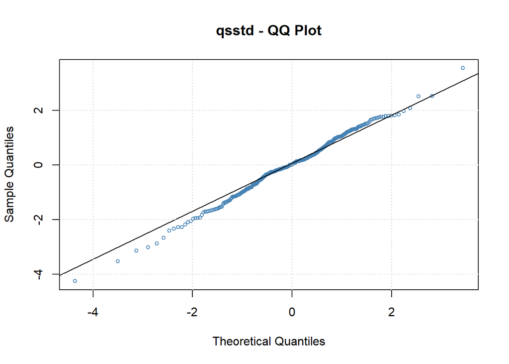

```r
plot(mod3, which=13)
```

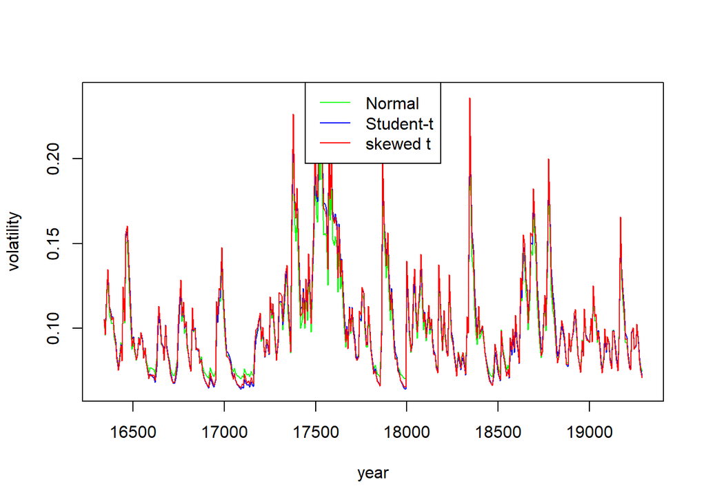

```r
x.btc <- as.vector(time(train_weeklyR))
vola1 <- fGarch::volatility(mod1)
vola2 <- fGarch::volatility(mod2)
vola3 <- fGarch::volatility(mod3)
matplot(x.btc, cbind(vola1, vola2, vola3),
        type="l",
        lty=1, col=c("green", "blue", "red"),
        xlab="year", ylab="volatility")
legend("top", lty=1, col=c("green", "blue", "red"),
       legend=c("Normal", "Student-t", "skewed t"))
```

```r
spec0=ugarchspec(variance.model=list(model="sGARCH",  garchOrder = c(1,1)),
                 mean.model=list(armaOrder=c(0,0),include.mean = TRUE),
                 distribution.model = 'norm')

mW0=ugarchfit(spec=spec0,data=train_weeklyR)
show(mW0)
```

```
##
## *---------------------------------*
## *          GARCH Model Fit        *
## *---------------------------------*
##
## Conditional Variance Dynamics
## -----------------------------------
## GARCH Model  : sGARCH(1,1)
## Mean Model   : ARFIMA(0,0,0)
## Distribution : norm
##
## Optimal Parameters
## ------------------------------------
##         Estimate  Std. Error  t value Pr(>|t|)
## mu      0.007635    0.004523   1.6879 0.091423
## omega   0.002068    0.000708   2.9228 0.003468
## alpha1  0.245528    0.074329   3.3033 0.000956
## beta1   0.570465    0.105235   5.4209 0.000000
##
## Robust Standard Errors:
##         Estimate  Std. Error  t value Pr(>|t|)
## mu      0.007635    0.004898   1.5587 0.119064
## omega   0.002068    0.000981   2.1081 0.035025
## alpha1  0.245528    0.083874   2.9273 0.003419
## beta1   0.570465    0.133256   4.2810 0.000019
##
## LogLikelihood : 381.5198
##
## Information Criteria
## ------------------------------------
##
## Akaike       -1.7892
## Bayes        -1.7509
## Shibata      -1.7894
## Hannan-Quinn -1.7740
##
## Weighted Ljung-Box Test on Standardized Residuals
## ------------------------------------
##                         statistic p-value
## Lag[1]                      3.463 0.06275
```

[output cut: 37 more lines]

```
## Negative Sign Bias  0.6196 0.5359
## Positive Sign Bias  0.2847 0.7761
## Joint Effect        0.6714 0.8799
##
##
## Adjusted Pearson Goodness-of-Fit Test:
## ------------------------------------
##   group statistic p-value(g-1)
## 1    20     41.22     0.002254
## 2    30     56.29     0.001744
## 3    40     63.88     0.007225
## 4    50     64.97     0.062923
##
##
## Elapsed time : 0.1715419
```

```
##
## please wait...calculating quantiles...
```

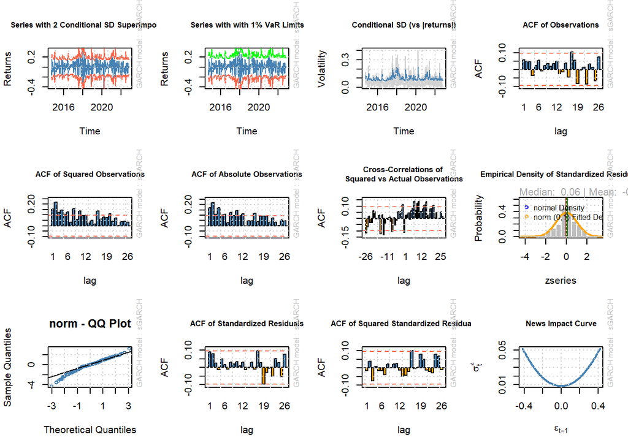

```r
plot(mW0, which='all')
```

```r
res_mW0=residuals(mW0,standardize=T)
Box.test(res_mW0,10,type="Ljung")
```

```
##
##  Box-Ljung test
##
## data:  res_mW0
## X-squared = 8.4641, df = 10, p-value = 0.5836
```

```r
Box.test(res_mW0^2,10,type="Ljung")
```

```
##
##  Box-Ljung test
##
## data:  res_mW0^2
## X-squared = 4.6295, df = 10, p-value = 0.9145
```

Tried eGARCH / iGARCH / gjrGARCH - adequate for weekly return gjrGARCH has the lowest AIC, then followed by sGARCH

```r
spec1=ugarchspec(variance.model=list(model="eGARCH",  garchOrder = c(1,1)),
                 mean.model=list(armaOrder=c(0,0),include.mean = TRUE) )

mW1=ugarchfit(spec=spec1,data=train_weeklyR)
show(mW1)
```

```
##
## *---------------------------------*
## *          GARCH Model Fit        *
## *---------------------------------*
##
## Conditional Variance Dynamics
## -----------------------------------
## GARCH Model  : eGARCH(1,1)
## Mean Model   : ARFIMA(0,0,0)
## Distribution : norm
##
## Optimal Parameters
## ------------------------------------
##         Estimate  Std. Error  t value Pr(>|t|)
## mu      0.008712    0.008678  1.00393 0.315413
## omega  -1.234725    0.364223 -3.39002 0.000699
## alpha1 -0.034001    0.043462 -0.78231 0.434032
## beta1   0.729245    0.078531  9.28606 0.000000
## gamma1  0.449749    0.102246  4.39869 0.000011
##
## Robust Standard Errors:
##         Estimate  Std. Error  t value Pr(>|t|)
## mu      0.008712    0.018704  0.46576 0.641384
## omega  -1.234725    0.614762 -2.00846 0.044594
## alpha1 -0.034001    0.070397 -0.48299 0.629105
## beta1   0.729245    0.133506  5.46225 0.000000
## gamma1  0.449749    0.140061  3.21110 0.001322
##
## LogLikelihood : 379.5286
##
## Information Criteria
## ------------------------------------
##
## Akaike       -1.7750
## Bayes        -1.7271
## Shibata      -1.7753
## Hannan-Quinn -1.7561
##
## Weighted Ljung-Box Test on Standardized Residuals
## ------------------------------------
```

[output cut: 40 more lines]

```
## Negative Sign Bias 0.88968 0.3742
## Positive Sign Bias 0.04901 0.9609
## Joint Effect       0.79392 0.8509
##
##
## Adjusted Pearson Goodness-of-Fit Test:
## ------------------------------------
##   group statistic p-value(g-1)
## 1    20     44.16    0.0008971
## 2    30     63.83    0.0002015
## 3    40     61.22    0.0130233
## 4    50     68.52    0.0341234
##
##
## Elapsed time : 0.1934822
```

```
##
## please wait...calculating quantiles...
```

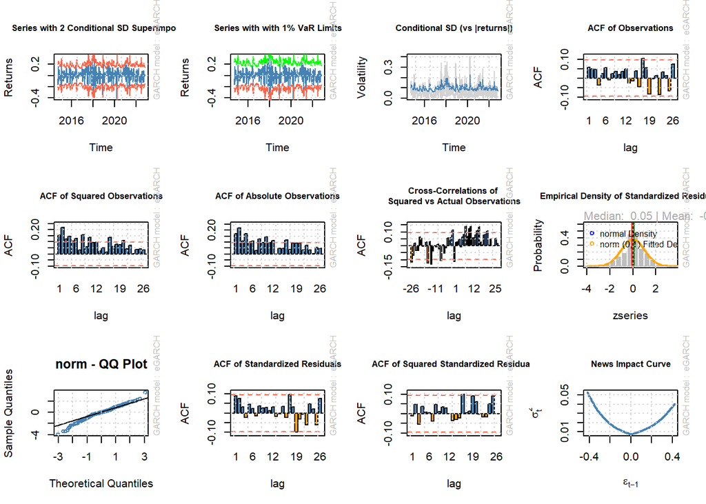

```r
plot(mW1, which='all')
```

```r
res_mW1=residuals(mW1,standardize=T)
Box.test(res_mW1,10,type="Ljung")
```

```
##
##  Box-Ljung test
##
## data:  res_mW1
## X-squared = 8.779, df = 10, p-value = 0.5532
```

```r
Box.test(res_mW1^2,10,type="Ljung")
```

```
##
##  Box-Ljung test
##
## data:  res_mW1^2
## X-squared = 5.1394, df = 10, p-value = 0.8817
```

```r
spec2=ugarchspec(variance.model=list(model="iGARCH",  garchOrder = c(1,1)),
                 mean.model=list(armaOrder=c(0,0),include.mean = TRUE) )

mW2=ugarchfit(spec=spec2,data=train_weeklyR)
show(mW2)
```

```
##
## *---------------------------------*
## *          GARCH Model Fit        *
## *---------------------------------*
##
## Conditional Variance Dynamics
## -----------------------------------
## GARCH Model  : iGARCH(1,1)
## Mean Model   : ARFIMA(0,0,0)
## Distribution : norm
##
## Optimal Parameters
## ------------------------------------
##         Estimate  Std. Error  t value Pr(>|t|)
## mu      0.008600    0.004475   1.9218 0.054627
## omega   0.001355    0.000477   2.8423 0.004478
## alpha1  0.417496    0.094574   4.4145 0.000010
## beta1   0.582504          NA       NA       NA
##
## Robust Standard Errors:
##         Estimate  Std. Error  t value Pr(>|t|)
## mu      0.008600    0.004251   2.0230 0.043069
## omega   0.001355    0.000787   1.7217 0.085128
## alpha1  0.417496    0.151514   2.7555 0.005860
## beta1   0.582504          NA       NA       NA
##
## LogLikelihood : 376.3892
##
## Information Criteria
## ------------------------------------
##
## Akaike       -1.7696
## Bayes        -1.7409
## Shibata      -1.7697
## Hannan-Quinn -1.7583
##
## Weighted Ljung-Box Test on Standardized Residuals
## ------------------------------------
##                         statistic p-value
## Lag[1]                      4.345 0.03711
```

[output cut: 36 more lines]

```
## Negative Sign Bias   1.489 0.1373
## Positive Sign Bias   1.078 0.2816
## Joint Effect         3.854 0.2776
##
##
## Adjusted Pearson Goodness-of-Fit Test:
## ------------------------------------
##   group statistic p-value(g-1)
## 1    20     47.86    0.0002689
## 2    30     65.82    0.0001106
## 3    40     65.58    0.0048763
## 4    50     82.27    0.0020470
##
##
## Elapsed time : 0.05585003
```

```
##
## please wait...calculating quantiles...
```

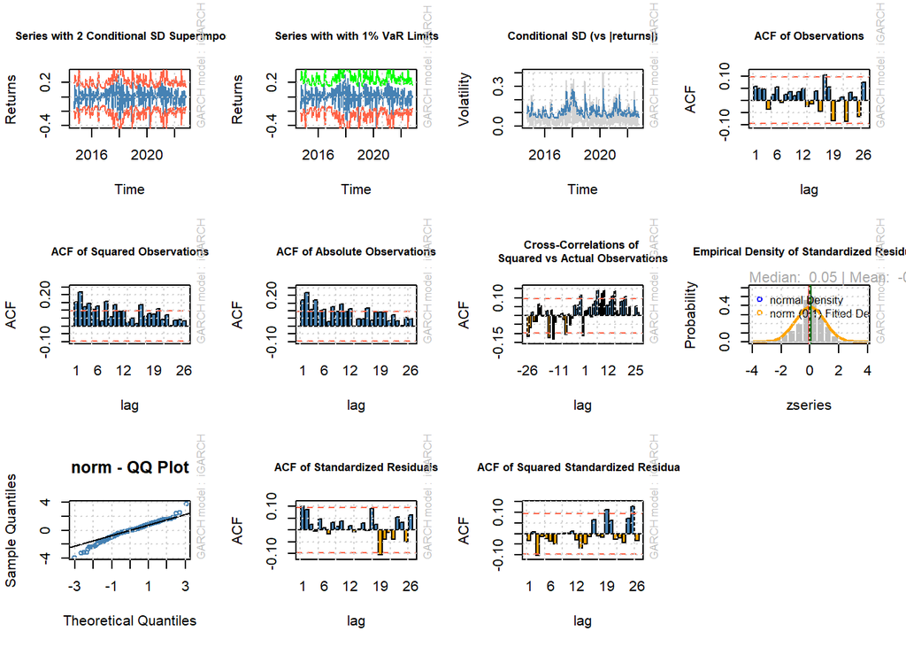

```r
plot(mW2, which='all')
```

```r
res_mW2=residuals(mW2,standardize=T)
Box.test(res_mW2,10,type="Ljung")
```

```
##
##  Box-Ljung test
##
## data:  res_mW2
## X-squared = 10.082, df = 10, p-value = 0.4334
```

```r
Box.test(res_mW2^2,10,type="Ljung")
```

```
##
##  Box-Ljung test
##
## data:  res_mW2^2
## X-squared = 6.8866, df = 10, p-value = 0.7361
```

```r
spec3=ugarchspec(variance.model=list(model="gjrGARCH",  garchOrder = c(1,1)),
                 mean.model=list(armaOrder=c(0,0),include.mean = TRUE) )

mW3=ugarchfit(spec=spec3,data=train_weeklyR)
show(mW3)
```

```
##
## *---------------------------------*
## *          GARCH Model Fit        *
## *---------------------------------*
##
## Conditional Variance Dynamics
## -----------------------------------
## GARCH Model  : gjrGARCH(1,1)
## Mean Model   : ARFIMA(0,0,0)
## Distribution : norm
##
## Optimal Parameters
## ------------------------------------
##         Estimate  Std. Error  t value Pr(>|t|)
## mu      0.009915     2.4e-05   420.20        0
## omega   0.000040     0.0e+00   748.34        0
## alpha1  0.046134     1.3e-05  3611.74        0
## beta1   0.999999     1.1e-04  9056.79        0
## gamma1 -0.094274     6.6e-05 -1438.33        0
##
## Robust Standard Errors:
##         Estimate  Std. Error  t value Pr(>|t|)
## mu      0.009915    0.000025   396.66        0
## omega   0.000040    0.000000   339.52        0
## alpha1  0.046134    0.000011  4378.32        0
## beta1   0.999999    0.000122  8226.47        0
## gamma1 -0.094274    0.000076 -1236.23        0
##
## LogLikelihood : 389.9861
##
## Information Criteria
## ------------------------------------
##
## Akaike       -1.8246
## Bayes        -1.7767
## Shibata      -1.8249
## Hannan-Quinn -1.8056
##
## Weighted Ljung-Box Test on Standardized Residuals
## ------------------------------------
```

[output cut: 40 more lines]

```
## Negative Sign Bias  2.0467 0.04132  **
## Positive Sign Bias  0.7305 0.46552
## Joint Effect        4.8312 0.18458
##
##
## Adjusted Pearson Goodness-of-Fit Test:
## ------------------------------------
##   group statistic p-value(g-1)
## 1    20     52.12    6.341e-05
## 2    30     68.38    5.036e-05
## 3    40     83.97    3.890e-05
## 4    50     89.14    4.001e-04
##
##
## Elapsed time : 0.6273229
```

```
##
## please wait...calculating quantiles...
```

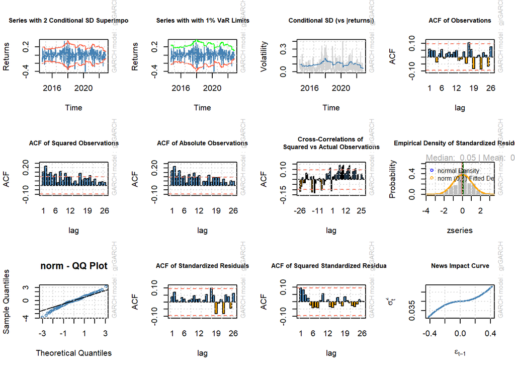

```r
plot(mW3, which='all')
```

```r
res_mW3=residuals(mW3,standardize=T)
Box.test(res_mW3,10,type="Ljung")
```

```
##
##  Box-Ljung test
##
## data:  res_mW3
## X-squared = 4.7936, df = 10, p-value = 0.9045
```

```r
Box.test(res_mW3^2,10,type="Ljung")
```

```
##
##  Box-Ljung test
##
## data:  res_mW3^2
## X-squared = 11.786, df = 10, p-value = 0.2996
```

```r
#plot(mW3@fit$var)
#plot(sigma(mW3))
```

Forecast with gjRGARCH(1,1) on weekly log return

5-step ahead prediction

```r
# estimate model excluding the out-of-sample

T <- nrow(diff1_log_btc_weekly)

out_of_sample <- round(T*.2)
dates_out_of_sample <- tail(index(diff1_log_btc_weekly), out_of_sample)
garch_spec <- ugarchspec(mean.model = list(armaOrder = c(0,0), include.mean = TRUE),
                         variance.model = list(model = "gjrGARCH", garchOrder = c(1,1)))
garch_fit <- ugarchfit(spec = garch_spec, data = diff1_log_btc_weekly, out.sample = out_of_sample)
coef(garch_fit)
```

```
##            mu         omega        alpha1         beta1        gamma1
##  1.497166e-02  7.727979e-05  5.077112e-02  1.000000e+00 -1.035422e-01
```

```r
# forecast log-returns along the whole out-of-sample
garch_fore <- ugarchforecast(garch_fit, n.ahead = h, n.roll = out_of_sample-1)
```

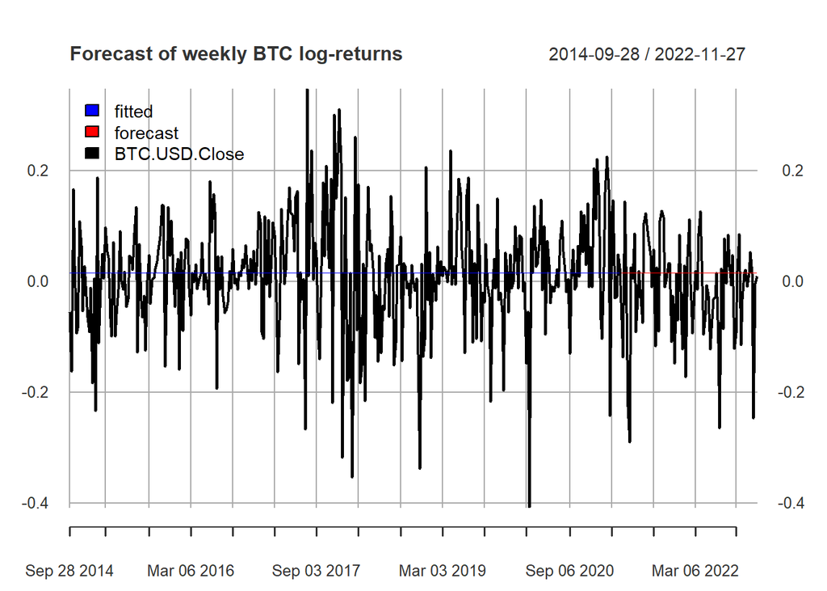

```r
forecast_log_returns <- xts(garch_fore@forecast$seriesFor[1, ], dates_out_of_sample)
forecast_volatility <- xts(garch_fore@forecast$sigmaFor[1, ], dates_out_of_sample)

# plot of log-returns
plot(cbind("fitted"   = fitted(garch_fit),
           "forecast" = forecast_log_returns,
           "original" = diff1_log_btc_weekly),
     col = c("blue", "red", "black"), lwd = c(0.5, 0.5, 2),
     main = "Forecast of weekly BTC log-returns", legend.loc = "topleft")
```

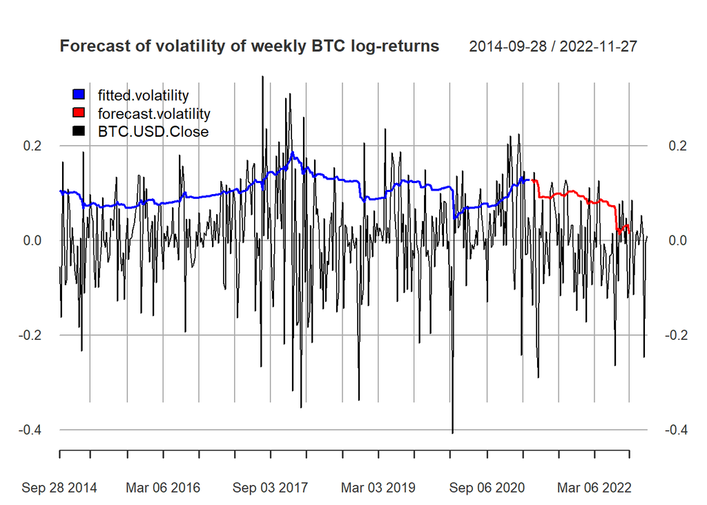

```r
# plot of volatility log-returns
plot(cbind("fitted volatility"   = sigma(garch_fit),
           "forecast volatility" = forecast_volatility,
           "log-returns"         = diff1_log_btc_weekly),
     col = c("blue", "red", "black"), lwd = c(2, 2, 1),
     main = "Forecast of volatility of weekly BTC log-returns", legend.loc = "topleft")
```

rolling window comparison

```r
# model specification of an eGARCH(1,1)
spec <- garch_spec

# static fit and forecast
static_fit <- ugarchfit(spec = spec, data = diff1_log_btc_weekly, out.sample = out_of_sample)
static_fore_logreturns <- xts(ugarchforecast(garch_fit, n.ahead = h, n.roll = out_of_sample-1)@forecast$seriesFor[1, ],
                                 dates_out_of_sample)
# rolling fit and forecast
modelroll <- ugarchroll(spec = spec, data = diff1_log_btc_weekly, n.ahead = 1,
                        forecast.length = out_of_sample, refit.every = 5, refit.window = "moving")
rolling_fore_logreturns <- xts(modelroll@forecast$density$Mu, dates_out_of_sample)

report(modelroll, type="VaR", VaR.alpha = 0.01, conf.level = 0.95)
```

```
## VaR Backtest Report
## ===========================================
## Model:               gjrGARCH-norm
## Backtest Length: 85
## Data:
##
## ==========================================
## alpha:               1%
## Expected Exceed: 0.8
## Actual VaR Exceed:   4
## Actual %:            4.7%
##
## Unconditional Coverage (Kupiec)
## Null-Hypothesis: Correct Exceedances
## LR.uc Statistic: 6.21
## LR.uc Critical:      3.841
## LR.uc p-value:       0.013
## Reject Null:     YES
##
## Conditional Coverage (Christoffersen)
## Null-Hypothesis: Correct Exceedances and
##                  Independence of Failures
## LR.cc Statistic: 6.61
## LR.cc Critical:      5.991
## LR.cc p-value:       0.037
## Reject Null:     YES
```

```r
report(modelroll, type="fpm")
```

```
##
## GARCH Roll Mean Forecast Performance Measures
## ---------------------------------------------
## Model        : gjrGARCH
## No.Refits    : 17
## No.Forecasts: 85
##
##       Stats
## MSE 0.00915
## MAE 0.07048
## DAC 0.48240
```

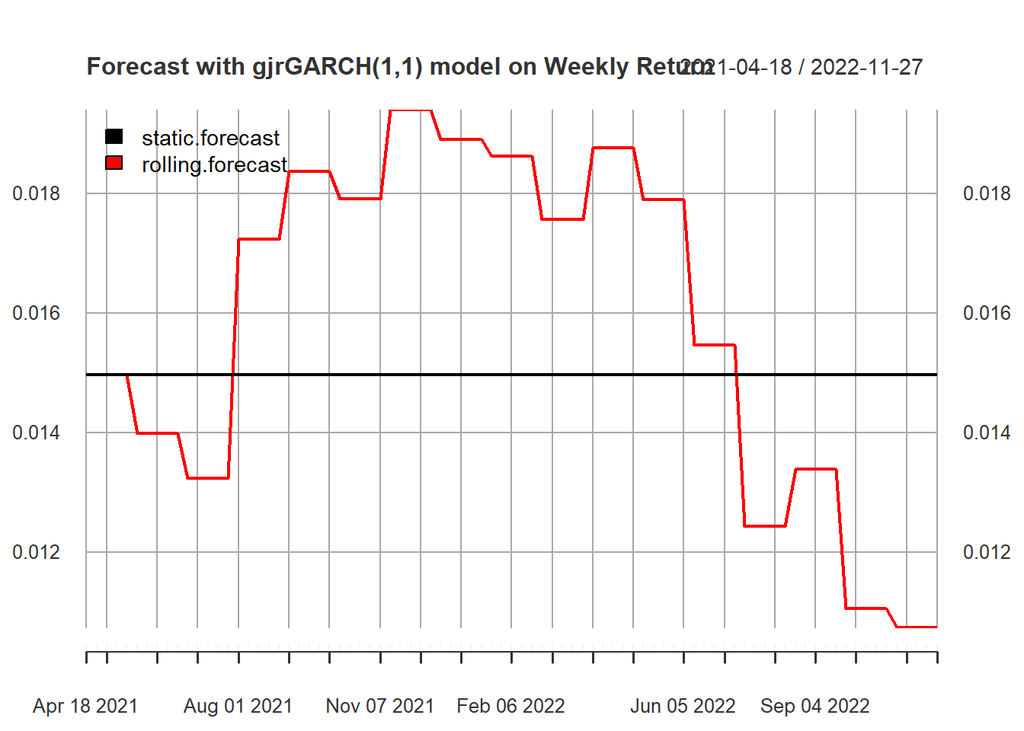

```r
# plot of forecast
plot(cbind("static forecast"  = static_fore_logreturns,
           "rolling forecast" = rolling_fore_logreturns),
     col = c("black", "red"), lwd = 2,
     main = "Forecast with gjrGARCH(1,1) model on Weekly Return", legend.loc = "topleft")
```

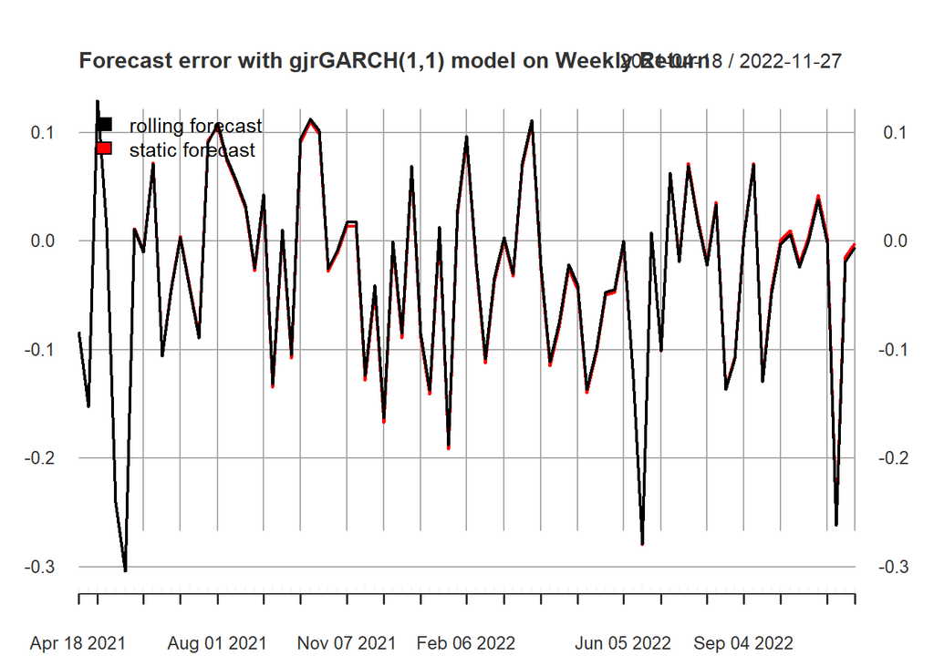

```r
# plot of forecast error
error_logreturns <- cbind(diff1_log_btc_weekly - static_fore_logreturns,
                          diff1_log_btc_weekly - rolling_fore_logreturns)
names(error_logreturns) <- c("rolling forecast", "static forecast")
plot(error_logreturns, col = c("black", "red"), lwd = 2,
     main = "Forecast error with gjrGARCH(1,1) model on Weekly Return", legend.loc = "topleft")
```

log return to price

```r
# simulate one path
garch_spec <- ugarchspec(mean.model = list(armaOrder = c(0,0), include.mean = TRUE),
                         variance.model = list(model = "gjrGARCH", garchOrder = c(1,1)),
                         fixed.pars = as.list(coef(garch_fit))
                                               )

T <- 36
path_garch <- ugarchpath(garch_spec, m.sim = 3, n.sim = T, rseed=1)

str(path_garch@path$seriesSim)
```

```
##  num [1:36, 1:3] -0.1593 0.0655 -0.2155 0.4469 0.1098 ...
```

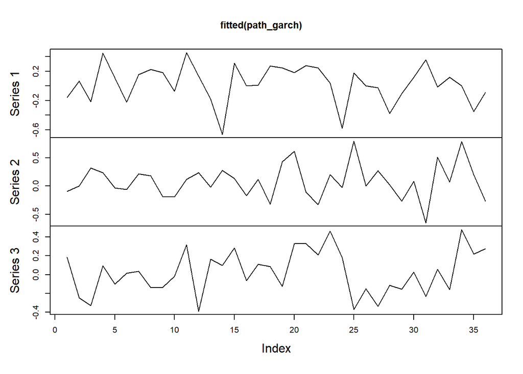

```r
plot.zoo(fitted(path_garch))
```

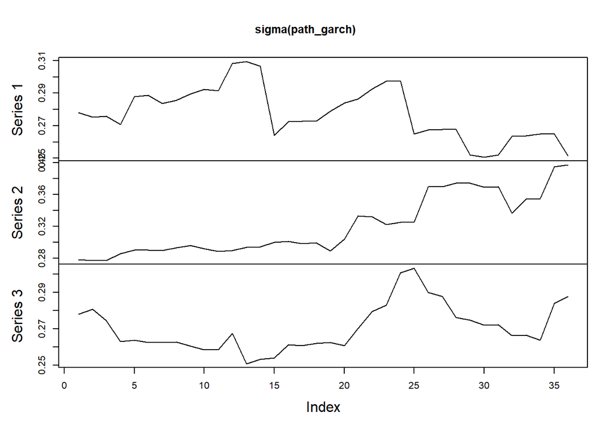

```r
plot.zoo(sigma(path_garch))
```

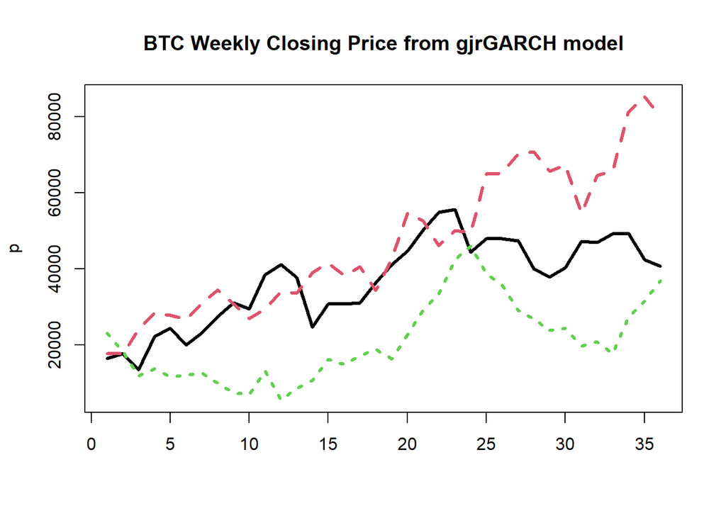

```r
fOrigin <- tail(index(train_weeklyR), 1)
fOriginPrice <- as.numeric(btc_weekly[fOrigin]$`BTC-USD.Close`)

p<-fOriginPrice*apply(fitted(path_garch),2,'cumsum') + fOriginPrice
matplot(p, type='l', lwd=3, main = "BTC Weekly Closing Price from gjrGARCH model")
```

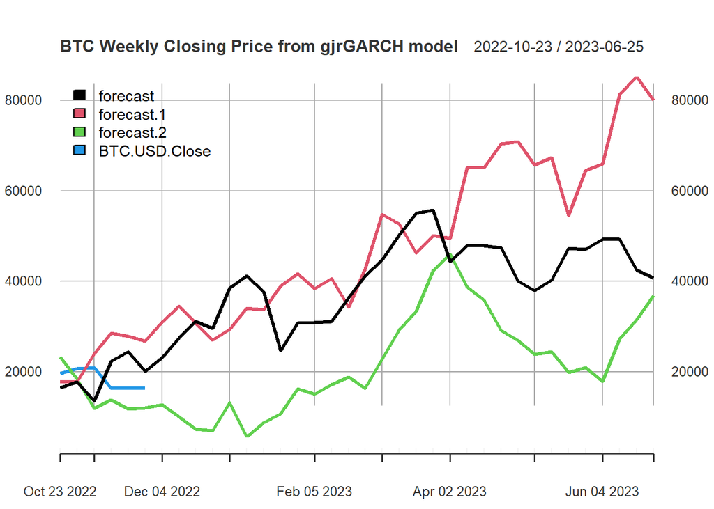

```r
d <- seq(as.Date(fOrigin),by='weeks',length=T)
p.xts <- xts(p, order.by=d)
plot(cbind("forecast"=p.xts,
           "actual"=window(btc_weekly,start=fOrigin)$`BTC-USD.Close`
           ),
     lwd=3, main = "BTC Weekly Closing Price from gjrGARCH model", legend.loc = "topleft")
```

### Monthly

look for mean model, recall significant spike at lag at 13 & 23

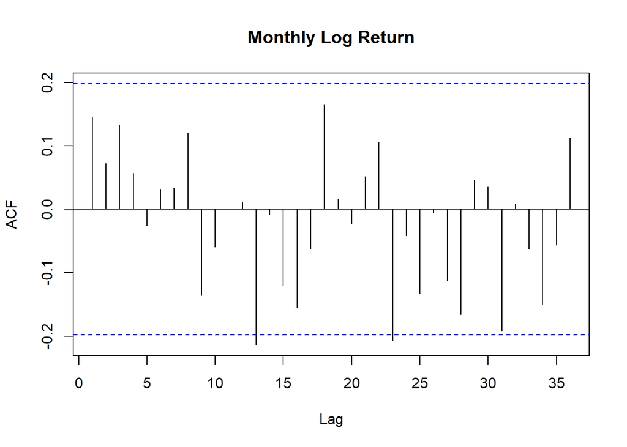

```r
acf <-acf(ts(diff1_log_btc_monthly), main='Monthly Log Return', lag=36)
```

```r
acf
```

```
##
## Autocorrelations of series 'ts(diff1_log_btc_monthly)', by lag
##
##      1      2      3      4      5      6      7      8      9     10     11
##  0.146  0.072  0.133  0.056 -0.025  0.031  0.033  0.120 -0.136 -0.060  0.001
##     12     13     14     15     16     17     18     19     20     21     22
##  0.011 -0.214 -0.009 -0.120 -0.155 -0.063  0.165  0.016 -0.023  0.052  0.105
##     23     24     25     26     27     28     29     30     31     32     33
## -0.207 -0.042 -0.133 -0.005 -0.113 -0.166  0.046  0.036 -0.192  0.008 -0.062
##     34     35     36
## -0.150 -0.056  0.112
```

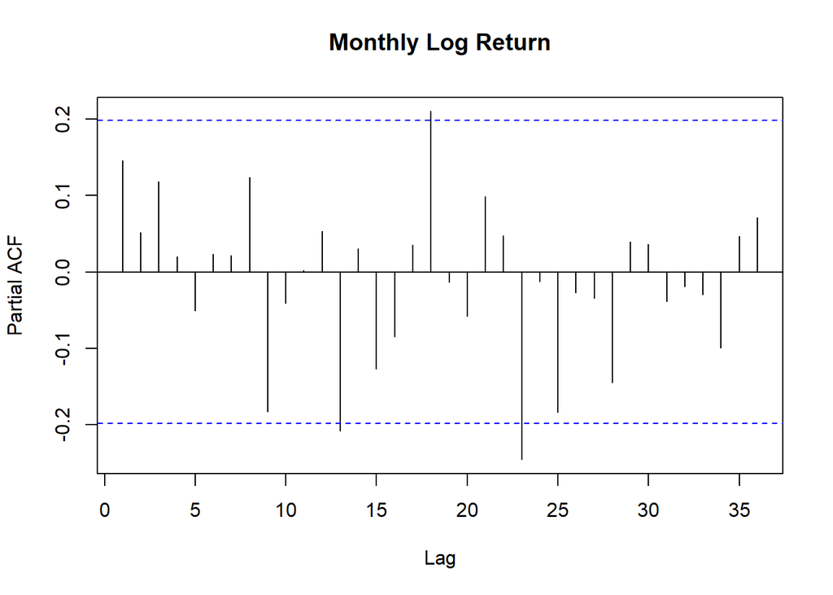

```r
pacf <- pacf(ts(diff1_log_btc_monthly),main='Monthly Log Return', lag=36)
```

```r
pacf
```

```
##
## Partial autocorrelations of series 'ts(diff1_log_btc_monthly)', by lag
##
##      1      2      3      4      5      6      7      8      9     10     11
##  0.146  0.052  0.118  0.020 -0.050  0.023  0.022  0.124 -0.182 -0.041  0.002
##     12     13     14     15     16     17     18     19     20     21     22
##  0.053 -0.208  0.030 -0.127 -0.085  0.035  0.210 -0.013 -0.058  0.098  0.048
##     23     24     25     26     27     28     29     30     31     32     33
## -0.245 -0.012 -0.183 -0.027 -0.035 -0.145  0.039  0.036 -0.038 -0.019 -0.029
##     34     35     36
## -0.099  0.047  0.071
```

```r
# try MA(13) and fix other coef to zero:
est = arima(diff1_log_btc_monthly,order=c(0,0,13),fixed=c(rep(0,12),NA,NA),seasonal=list(order=c(0,0,0),period=12))
est
```

```
##
## Call:
## arima(x = diff1_log_btc_monthly, order = c(0, 0, 13), seasonal = list(order = c(0,
##     0, 0), period = 12), fixed = c(rep(0, 12), NA, NA))
##
## Coefficients:
##       ma1  ma2  ma3  ma4  ma5  ma6  ma7  ma8  ma9  ma10  ma11  ma12     ma13
##         0    0    0    0    0    0    0    0    0     0     0     0  -0.2465
## s.e.    0    0    0    0    0    0    0    0    0     0     0     0   0.1022
##       intercept
##          0.0438
## s.e.     0.0166
##
## sigma^2 estimated as 0.04298:  log likelihood = 14.74,  aic = -25.49
```

```r
jointTest= Box.test(est$residuals, lag=24, type="Ljung")
jointTest
```

```
##
##  Box-Ljung test
##
## data:  est$residuals
## X-squared = 22.16, df = 24, p-value = 0.5697
```

```r
pv=1-pchisq(jointTest$statistic[1],23) #Compute p-value using 8 degrees of freedom
names(pv) <- 'pv'
pv #0.5137
```

```
##        pv
## 0.5106171
```

```r
# try AR(13) and fix other coef to zero:
est = arima(diff1_log_btc_monthly,order=c(13,0,0),fixed=c(rep(0,12),NA,NA),seasonal=list(order=c(0,0,0),period=12))
est
```

```
##
## Call:
## arima(x = diff1_log_btc_monthly, order = c(13, 0, 0), seasonal = list(order = c(0,
##     0, 0), period = 12), fixed = c(rep(0, 12), NA, NA))
##
## Coefficients:
##       ar1  ar2  ar3  ar4  ar5  ar6  ar7  ar8  ar9  ar10  ar11  ar12     ar13
##         0    0    0    0    0    0    0    0    0     0     0     0  -0.2418
## s.e.    0    0    0    0    0    0    0    0    0     0     0     0   0.1033
##       intercept
##          0.0435
## s.e.     0.0174
##
## sigma^2 estimated as 0.04305:  log likelihood = 14.68,  aic = -25.35
```

```r
jointTest= Box.test(est$residuals, lag=24, type="Ljung")
jointTest
```

```
##
##  Box-Ljung test
##
## data:  est$residuals
## X-squared = 22.567, df = 24, p-value = 0.5455
```

```r
pv=1-pchisq(jointTest$statistic[1],23) #Compute p-value using 8 degrees of freedom
names(pv) <- 'pv'
pv # 0.4895
```

```
##        pv
## 0.4862749
```

```r
# try ARMA(13,13) and fix other coef to zero: - NOT significant
est = arima(diff1_log_btc_monthly,order=c(13,0,13),
            fixed=c(rep(0,12),NA,rep(0,12),NA,NA),
            seasonal=list(order=c(0,0,0),period=12))
est
```

```
##
## Call:
## arima(x = diff1_log_btc_monthly, order = c(13, 0, 13), seasonal = list(order = c(0,
##     0, 0), period = 12), fixed = c(rep(0, 12), NA, rep(0, 12), NA, NA))
##
## Coefficients:
##       ar1  ar2  ar3  ar4  ar5  ar6  ar7  ar8  ar9  ar10  ar11  ar12     ar13
##         0    0    0    0    0    0    0    0    0     0     0     0  -0.1018
## s.e.    0    0    0    0    0    0    0    0    0     0     0     0   0.3365
##       ma1  ma2  ma3  ma4  ma5  ma6  ma7  ma8  ma9  ma10  ma11  ma12     ma13
##         0    0    0    0    0    0    0    0    0     0     0     0  -0.1532
## s.e.    0    0    0    0    0    0    0    0    0     0     0     0   0.3319
##       intercept
##          0.0439
## s.e.     0.0168
##
## sigma^2 estimated as 0.04293:  log likelihood = 14.79,  aic = -23.57
```

```r
jointTest= Box.test(est$residuals, lag=24, type="Ljung")
jointTest
```

```
##
##  Box-Ljung test
##
## data:  est$residuals
## X-squared = 22.206, df = 24, p-value = 0.567
```

```r
pv=1-pchisq(jointTest$statistic[1],23) #Compute p-value using 8 degrees of freedom
names(pv) <- 'pv'
pv #0.5111164
```

```
##        pv
## 0.5078531
```

```r
# look for arima model if applicable
mm_monthly <- auto.arima(log_btc_monthly)
mm_monthly
```

```
## Series: log_btc_monthly
## ARIMA(0,1,0) with drift
##
## Coefficients:
##        drift
##       0.0383
## s.e.  0.0216
##
## sigma^2 = 0.04625:  log likelihood = 12.06
## AIC=-20.12   AICc=-19.99   BIC=-14.95
```

```r
# conclusion: best model is the mean model.try MA(13) if insist on using ARMA as the mean model
```

volatility model for monthly return sGARCH - adequate

```r
spec0=ugarchspec(variance.model=list(model="sGARCH",  garchOrder = c(1,1)),
                 mean.model=list(armaOrder=c(0,13),include.mean = TRUE),
                 fixed.pars=list(ma1=0, ma2=0, ma3=0, ma4=0, ma5=0, ma6=0, ma7=0, ma8=0, ma9=0, ma10=0,
                                 ma11=0, ma12=0, omega=0, alpha1=0)
                 )

mM0=ugarchfit(spec=spec0,data=train_monthlyR)
show(mM0)
```

```
##
## *---------------------------------*
## *          GARCH Model Fit        *
## *---------------------------------*
##
## Conditional Variance Dynamics
## -----------------------------------
## GARCH Model  : sGARCH(1,1)
## Mean Model   : ARFIMA(0,0,13)
## Distribution : norm
##
## Optimal Parameters
## ------------------------------------
##         Estimate  Std. Error  t value Pr(>|t|)
## mu      0.045838    0.017653   2.5966 0.009414
## ma1     0.000000          NA       NA       NA
## ma2     0.000000          NA       NA       NA
## ma3     0.000000          NA       NA       NA
## ma4     0.000000          NA       NA       NA
## ma5     0.000000          NA       NA       NA
## ma6     0.000000          NA       NA       NA
## ma7     0.000000          NA       NA       NA
## ma8     0.000000          NA       NA       NA
## ma9     0.000000          NA       NA       NA
## ma10    0.000000          NA       NA       NA
## ma11    0.000000          NA       NA       NA
## ma12    0.000000          NA       NA       NA
## ma13   -0.232489    0.107090  -2.1710 0.029933
## omega   0.000000          NA       NA       NA
## alpha1  0.000000          NA       NA       NA
## beta1   0.999000    0.003012 331.7022 0.000000
##
## Robust Standard Errors:
##         Estimate  Std. Error  t value Pr(>|t|)
## mu      0.045838    0.018641   2.4590 0.013932
## ma1     0.000000          NA       NA       NA
## ma2     0.000000          NA       NA       NA
## ma3     0.000000          NA       NA       NA
## ma4     0.000000          NA       NA       NA
## ma5     0.000000          NA       NA       NA
```

[output cut: 62 more lines]

```
## Negative Sign Bias 0.40767 0.6845
## Positive Sign Bias 0.30378 0.7620
## Joint Effect       0.25867 0.9676
##
##
## Adjusted Pearson Goodness-of-Fit Test:
## ------------------------------------
##   group statistic p-value(g-1)
## 1    20      8.29       0.9835
## 2    30     16.35       0.9713
## 3    40     27.86       0.9081
## 4    50     31.19       0.9777
##
##
## Elapsed time : 0.1316481
```

```
##
## please wait...calculating quantiles...
```

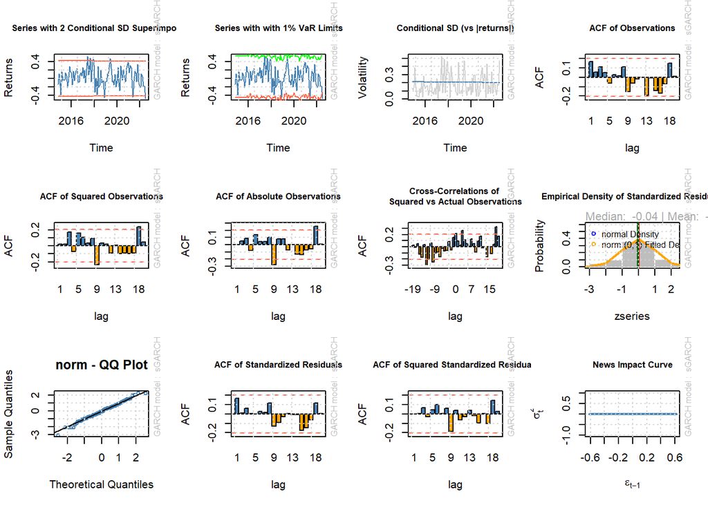

```r
plot(mM0, which='all')
```

```r
res_mM0=residuals(mM0,standardize=T)
Box.test(res_mM0,10,type="Ljung")
```

```
##
##  Box-Ljung test
##
## data:  res_mM0
## X-squared = 7.3682, df = 10, p-value = 0.6903
```

```r
Box.test(res_mM0^2,10,type="Ljung")
```

```
##
##  Box-Ljung test
##
## data:  res_mM0^2
## X-squared = 5.8368, df = 10, p-value = 0.8288
```

eGARCH / iGARCH / gjrGARCH - all adequate for monthly return compare AIC, eGARCH is the winner here. note the news impact curve is not symmetric compared with sGARCH

```r
spec1=ugarchspec(variance.model=list(model="eGARCH",  garchOrder = c(1,1)),
                 mean.model=list(armaOrder=c(0,13),include.mean = TRUE)
                 )

mM1=ugarchfit(spec=spec1,data=train_monthlyR)
show(mM1)
```

```
##
## *---------------------------------*
## *          GARCH Model Fit        *
## *---------------------------------*
##
## Conditional Variance Dynamics
## -----------------------------------
## GARCH Model  : eGARCH(1,1)
## Mean Model   : ARFIMA(0,0,13)
## Distribution : norm
##
## Optimal Parameters
## ------------------------------------
##         Estimate  Std. Error   t value Pr(>|t|)
## mu     -0.008554    0.000001 -8067.642        0
## ma1     0.045009    0.000041  1099.799        0
## ma2    -0.194810    0.000052 -3731.072        0
## ma3    -0.123677    0.000041 -2994.724        0
## ma4    -0.345490    0.000108 -3203.501        0
## ma5    -0.303820    0.000164 -1851.263        0
## ma6    -0.050421    0.000043 -1169.508        0
## ma7     0.044487    0.000054   820.974        0
## ma8     0.282382    0.000086  3278.040        0
## ma9    -0.160050    0.000056 -2846.814        0
## ma10   -0.347754    0.000063 -5504.004        0
## ma11   -0.324214    0.000198 -1640.842        0
## ma12   -0.395475    0.000111 -3578.367        0
## ma13   -0.450318    0.000071 -6301.290        0
## omega  -0.494108    0.000391 -1265.295        0
## alpha1  0.213640    0.000304   703.305        0
## beta1   0.844354    0.003370   250.521        0
## gamma1 -0.055996    0.000567   -98.692        0
##
## Robust Standard Errors:
##         Estimate  Std. Error    t value Pr(>|t|)
## mu     -0.008554    0.000000 -17364.697        0
## ma1     0.045009    0.000128    352.100        0
## ma2    -0.194810    0.000067  -2890.974        0
## ma3    -0.123677    0.000048  -2581.227        0
## ma4    -0.345490    0.000284  -1218.268        0
```

[output cut: 79 more lines]

```
## Negative Sign Bias  1.7848 0.07774   *
## Positive Sign Bias  0.6435 0.52156
## Joint Effect        5.1724 0.15960
##
##
## Adjusted Pearson Goodness-of-Fit Test:
## ------------------------------------
##   group statistic p-value(g-1)
## 1    20     17.75      0.53901
## 2    30     45.39      0.02697
## 3    40     51.09      0.09308
## 4    50     64.53      0.06762
##
##
## Elapsed time : 0.8457379
```

```
##
## please wait...calculating quantiles...
```

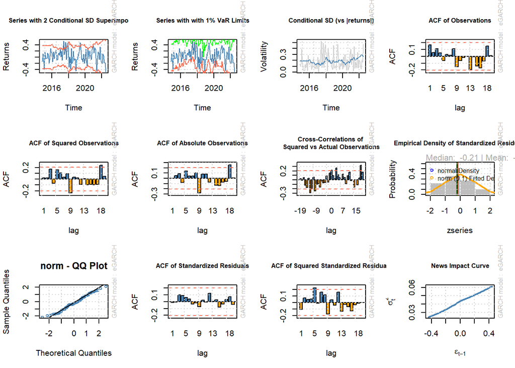

```r
plot(mM1, which='all')
```

```r
res_mM1=residuals(mM1,standardize=T)
Box.test(res_mM1,10,type="Ljung")
```

```
##
##  Box-Ljung test
##
## data:  res_mM1
## X-squared = 3.1986, df = 10, p-value = 0.9764
```

```r
Box.test(res_mM1^2,10,type="Ljung")
```

```
##
##  Box-Ljung test
##
## data:  res_mM1^2
## X-squared = 14.697, df = 10, p-value = 0.1435
```

```r
spec2=ugarchspec(variance.model=list(model="iGARCH",  garchOrder = c(1,1)),
                 mean.model=list(armaOrder=c(0,13),include.mean = TRUE),
                 fixed.pars=list(ma1=0, ma2=0, ma3=0, ma4=0, ma5=0, ma6=0, ma7=0, ma8=0, ma9=0, ma10=0,
                                 ma11=0, ma12=0, omega=0, alpha1=0)
                                  )

mM2=ugarchfit(spec=spec2,data=train_monthlyR)
mM2
```

```
##
## *---------------------------------*
## *          GARCH Model Fit        *
## *---------------------------------*
##
## Conditional Variance Dynamics
## -----------------------------------
## GARCH Model  : iGARCH(1,1)
## Mean Model   : ARFIMA(0,0,13)
## Distribution : norm
##
## Optimal Parameters
## ------------------------------------
##         Estimate  Std. Error  t value Pr(>|t|)
## mu      0.046252    0.017514   2.6408 0.008271
## ma1     0.000000          NA       NA       NA
## ma2     0.000000          NA       NA       NA
## ma3     0.000000          NA       NA       NA
## ma4     0.000000          NA       NA       NA
## ma5     0.000000          NA       NA       NA
## ma6     0.000000          NA       NA       NA
## ma7     0.000000          NA       NA       NA
## ma8     0.000000          NA       NA       NA
## ma9     0.000000          NA       NA       NA
## ma10    0.000000          NA       NA       NA
## ma11    0.000000          NA       NA       NA
## ma12    0.000000          NA       NA       NA
## ma13   -0.235161    0.106880  -2.2002 0.027790
## omega   0.000000          NA       NA       NA
## alpha1  0.000000          NA       NA       NA
## beta1   1.000000          NA       NA       NA
##
## Robust Standard Errors:
##         Estimate  Std. Error  t value Pr(>|t|)
## mu      0.046252    0.017971   2.5736 0.010063
## ma1     0.000000          NA       NA       NA
## ma2     0.000000          NA       NA       NA
## ma3     0.000000          NA       NA       NA
## ma4     0.000000          NA       NA       NA
## ma5     0.000000          NA       NA       NA
```

[output cut: 61 more lines]

```
## Negative Sign Bias  0.3943 0.6943
## Positive Sign Bias  0.3011 0.7640
## Joint Effect        0.2467 0.9697
##
##
## Adjusted Pearson Goodness-of-Fit Test:
## ------------------------------------
##   group statistic p-value(g-1)
## 1    20      7.00       0.9942
## 2    30     13.13       0.9950
## 3    40     26.14       0.9428
## 4    50     31.19       0.9777
##
##
## Elapsed time : 0.04986691
```

```
##
## please wait...calculating quantiles...
```

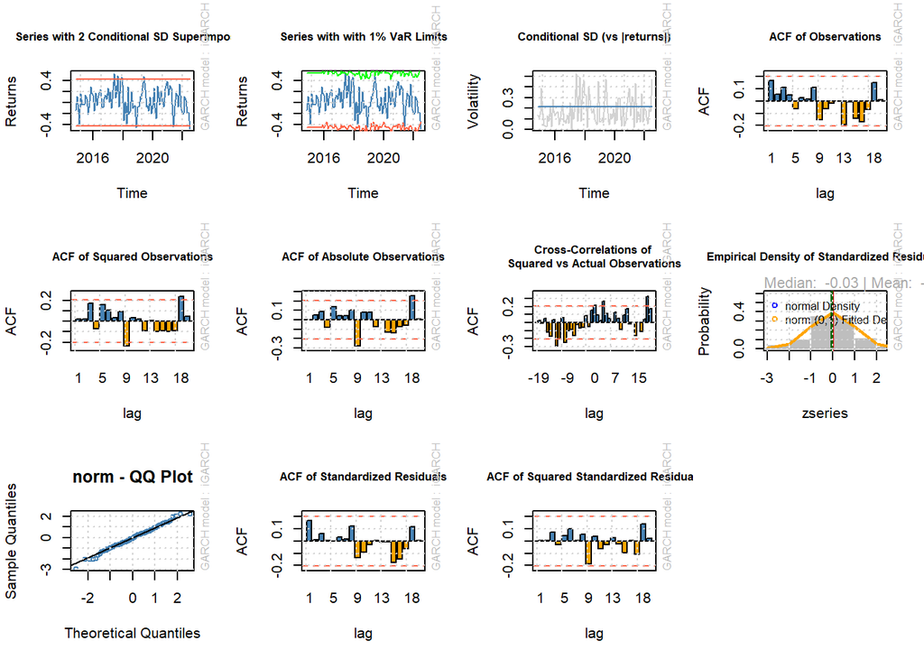

```r
plot(mM2, which='all')
```

```r
res_mM2=residuals(mM2,standardize=T)
Box.test(res_mM2,10,type="Ljung")
```

```
##
##  Box-Ljung test
##
## data:  res_mM2
## X-squared = 7.3992, df = 10, p-value = 0.6873
```

```r
Box.test(res_mM2^2,10,type="Ljung")
```

```
##
##  Box-Ljung test
##
## data:  res_mM2^2
## X-squared = 5.9559, df = 10, p-value = 0.819
```

```r
spec3=ugarchspec(variance.model=list(model="gjrGARCH",  garchOrder = c(1,1)),
                 mean.model=list(armaOrder=c(0,13),include.mean = TRUE),
                 fixed.pars=list(ma1=0, ma2=0, ma3=0, ma4=0, ma5=0, ma6=0, ma7=0, ma8=0, ma9=0, ma10=0,
                                 ma11=0, ma12=0, alpha1=0) )

mM3=ugarchfit(spec=spec3,data=train_monthlyR)
mM3
```

```
##
## *---------------------------------*
## *          GARCH Model Fit        *
## *---------------------------------*
##
## Conditional Variance Dynamics
## -----------------------------------
## GARCH Model  : gjrGARCH(1,1)
## Mean Model   : ARFIMA(0,0,13)
## Distribution : norm
##
## Optimal Parameters
## ------------------------------------
##         Estimate  Std. Error  t value Pr(>|t|)
## mu      0.031599    0.000163   193.64        0
## ma1     0.000000          NA       NA       NA
## ma2     0.000000          NA       NA       NA
## ma3     0.000000          NA       NA       NA
## ma4     0.000000          NA       NA       NA
## ma5     0.000000          NA       NA       NA
## ma6     0.000000          NA       NA       NA
## ma7     0.000000          NA       NA       NA
## ma8     0.000000          NA       NA       NA
## ma9     0.000000          NA       NA       NA
## ma10    0.000000          NA       NA       NA
## ma11    0.000000          NA       NA       NA
## ma12    0.000000          NA       NA       NA
## ma13   -0.223862    0.001139  -196.55        0
## omega   0.010301    0.000024   431.40        0
## alpha1  0.000000          NA       NA       NA
## beta1   0.892071    0.000749  1191.23        0
## gamma1 -0.310160    0.000992  -312.67        0
##
## Robust Standard Errors:
##         Estimate  Std. Error  t value Pr(>|t|)
## mu      0.031599    0.009158   3.4505 0.000560
## ma1     0.000000          NA       NA       NA
## ma2     0.000000          NA       NA       NA
## ma3     0.000000          NA       NA       NA
## ma4     0.000000          NA       NA       NA
```

[output cut: 66 more lines]

```
## Negative Sign Bias  1.6631 0.09985   *
## Positive Sign Bias  0.1813 0.85653
## Joint Effect        4.3887 0.22243
##
##
## Adjusted Pearson Goodness-of-Fit Test:
## ------------------------------------
##   group statistic p-value(g-1)
## 1    20     14.74       0.7389
## 2    30     20.23       0.8858
## 3    40     24.42       0.9671
## 4    50     35.49       0.9258
##
##
## Elapsed time : 0.772938
```

```
##
## please wait...calculating quantiles...
```

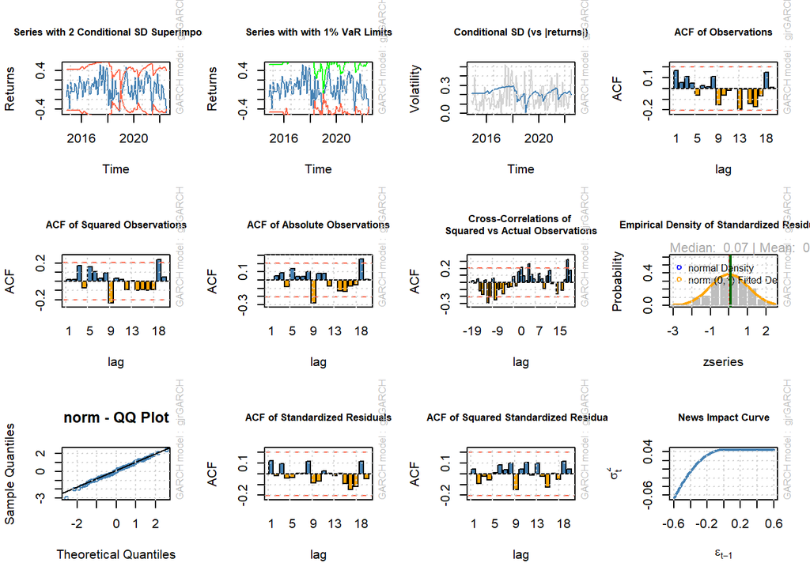

```r
plot(mM3, which='all')
```

```r
res_mM3=residuals(mM3,standardize=T)
Box.test(res_mM3,10,type="Ljung")
```

```
##
##  Box-Ljung test
##
## data:  res_mM3
## X-squared = 5.4159, df = 10, p-value = 0.8617
```

```r
Box.test(res_mM3^2,10,type="Ljung")
```

```
##
##  Box-Ljung test
##
## data:  res_mM3^2
## X-squared = 5.731, df = 10, p-value = 0.8373
```

```r
spec5=ugarchspec(variance.model=list(model="gjrGARCH",  garchOrder = c(1,2)),
                 mean.model=list(armaOrder=c(0,13),include.mean = TRUE),
                 fixed.pars=list(ma1=0, ma2=0, ma3=0, ma4=0, ma5=0, ma6=0, ma7=0, ma8=0, ma9=0, ma10=0,
                                 ma11=0, ma12=0, alpha1=0) )

mM5=ugarchfit(spec=spec5,data=train_monthlyR)
mM5
```

```
##
## *---------------------------------*
## *          GARCH Model Fit        *
## *---------------------------------*
##
## Conditional Variance Dynamics
## -----------------------------------
## GARCH Model  : gjrGARCH(1,2)
## Mean Model   : ARFIMA(0,0,13)
## Distribution : norm
##
## Optimal Parameters
## ------------------------------------
##         Estimate  Std. Error     t value Pr(>|t|)
## mu      0.045321    0.004145  1.0935e+01 0.000000
## ma1     0.000000          NA          NA       NA
## ma2     0.000000          NA          NA       NA
## ma3     0.000000          NA          NA       NA
## ma4     0.000000          NA          NA       NA
## ma5     0.000000          NA          NA       NA
## ma6     0.000000          NA          NA       NA
## ma7     0.000000          NA          NA       NA
## ma8     0.000000          NA          NA       NA
## ma9     0.000000          NA          NA       NA
## ma10    0.000000          NA          NA       NA
## ma11    0.000000          NA          NA       NA
## ma12    0.000000          NA          NA       NA
## ma13   -0.214342    0.097288 -2.2032e+00 0.027583
## omega   0.000000    0.000153  1.0000e-06 0.999999
## alpha1  0.000000          NA          NA       NA
## beta1   0.096354    0.000539  1.7891e+02 0.000000
## beta2   0.953517    0.000049  1.9545e+04 0.000000
## gamma1 -0.146390    0.003304 -4.4311e+01 0.000000
##
## Robust Standard Errors:
##         Estimate  Std. Error     t value Pr(>|t|)
## mu      0.045321    0.002870  1.5789e+01 0.000000
## ma1     0.000000          NA          NA       NA
## ma2     0.000000          NA          NA       NA
## ma3     0.000000          NA          NA       NA
```

[output cut: 69 more lines]

```
## Negative Sign Bias 0.99220 0.3238
## Positive Sign Bias 0.08042 0.9361
## Joint Effect       1.14387 0.7665
##
##
## Adjusted Pearson Goodness-of-Fit Test:
## ------------------------------------
##   group statistic p-value(g-1)
## 1    20     14.31       0.7652
## 2    30     19.58       0.9055
## 3    40     32.42       0.7628
## 4    50     45.46       0.6173
##
##
## Elapsed time : 0.376992
```

```
##
## please wait...calculating quantiles...
```

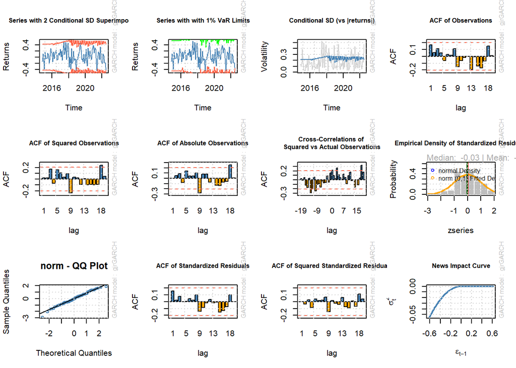

```r
plot(mM5, which='all')
```

```r
res_mM5=residuals(mM5,standardize=T)
Box.test(res_mM5,10,type="Ljung")
```

```
##
##  Box-Ljung test
##
## data:  res_mM5
## X-squared = 7.0832, df = 10, p-value = 0.7176
```

```r
Box.test(res_mM5^2,10,type="Ljung")
```

```
##
##  Box-Ljung test
##
## data:  res_mM5^2
## X-squared = 3.9327, df = 10, p-value = 0.9503
```

```r
spec4=ugarchspec(variance.model=list(model="sGARCH", garchOrder=c(1,1)),
                 mean.model=list(armaOrder=c(0,13),archm=T,archpow=2,include.mean = TRUE),
                 distribution.model='norm',
                 fixed.pars=list(ma1=0, ma2=0, ma3=0, ma4=0, ma5=0, ma6=0, ma7=0, ma8=0, ma9=0, ma10=0,
                                       ma11=0, ma12=0, alpha1=0))

mM4=ugarchfit(spec=spec4,data=train_monthlyR)
mM4
```

```
##
## *---------------------------------*
## *          GARCH Model Fit        *
## *---------------------------------*
##
## Conditional Variance Dynamics
## -----------------------------------
## GARCH Model  : sGARCH(1,1)
## Mean Model   : ARFIMA(0,0,13)
## Distribution : norm
##
## Optimal Parameters
## ------------------------------------
##         Estimate  Std. Error  t value Pr(>|t|)
## mu      0.053524    0.054862  0.97562 0.329255
## ma1     0.000000          NA       NA       NA
## ma2     0.000000          NA       NA       NA
## ma3     0.000000          NA       NA       NA
## ma4     0.000000          NA       NA       NA
## ma5     0.000000          NA       NA       NA
## ma6     0.000000          NA       NA       NA
## ma7     0.000000          NA       NA       NA
## ma8     0.000000          NA       NA       NA
## ma9     0.000000          NA       NA       NA
## ma10    0.000000          NA       NA       NA
## ma11    0.000000          NA       NA       NA
## ma12    0.000000          NA       NA       NA
## ma13   -0.240176    0.107473 -2.23476 0.025433
## archm  -0.148314    1.179592 -0.12573 0.899943
## omega   0.000166    0.000950  0.17519 0.860931
## alpha1  0.000000          NA       NA       NA
## beta1   0.999000    0.019846 50.33717 0.000000
##
## Robust Standard Errors:
##         Estimate  Std. Error   t value Pr(>|t|)
## mu      0.053524    0.014061   3.80666 0.000141
## ma1     0.000000          NA        NA       NA
## ma2     0.000000          NA        NA       NA
## ma3     0.000000          NA        NA       NA
## ma4     0.000000          NA        NA       NA
```

[output cut: 66 more lines]

```
## Negative Sign Bias  0.3512 0.7263
## Positive Sign Bias  0.2930 0.7702
## Joint Effect        0.2261 0.9733
##
##
## Adjusted Pearson Goodness-of-Fit Test:
## ------------------------------------
##   group statistic p-value(g-1)
## 1    20      8.72       0.9778
## 2    30     20.87       0.8638
## 3    40     23.56       0.9759
## 4    50     48.40       0.4974
##
##
## Elapsed time : 0.799861
```

```
##
## please wait...calculating quantiles...
```

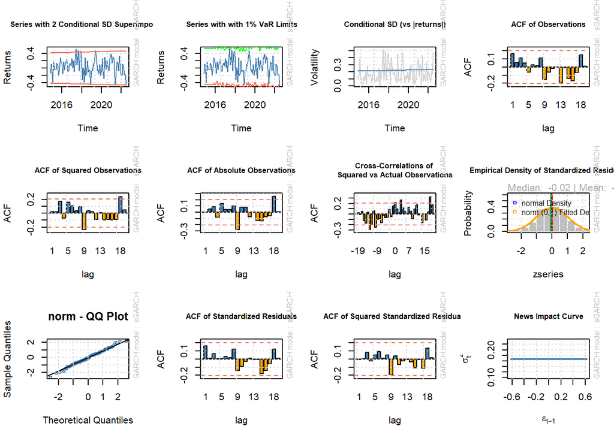

```r
plot(mM4, which='all')
```

```r
res_mM4=residuals(mM4,standardize=T)
Box.test(res_mM4,10,type="Ljung")
```

```
##
##  Box-Ljung test
##
## data:  res_mM4
## X-squared = 7.5006, df = 10, p-value = 0.6775
```

```r
Box.test(res_mM4^2,10,type="Ljung")
```

```
##
##  Box-Ljung test
##
## data:  res_mM4^2
## X-squared = 6.2657, df = 10, p-value = 0.7925
```

Forecast with gjrGARCH(1,1) on monthly log return

5-step ahead prediction

```r
# estimate model excluding the out-of-sample

T <- nrow(diff1_log_btc_monthly)

out_of_sample <- round(T*.2)
dates_out_of_sample <- tail(index(diff1_log_btc_monthly), out_of_sample)
# garch_spec <- ugarchspec(mean.model = list(armaOrder = c(0,0), include.mean = TRUE),
#                          variance.model = list(model = "eGARCH", garchOrder = c(1,1)))

garch_spec <- ugarchspec(variance.model=list(model="gjrGARCH",  garchOrder = c(1,1)),
                 mean.model=list(armaOrder=c(0,13),include.mean = TRUE),
                 fixed.pars=list(ma1=0, ma2=0, ma3=0, ma4=0, ma5=0, ma6=0, ma7=0, ma8=0, ma9=0, ma10=0,
                                 ma11=0, ma12=0, alpha1=0) )

garch_fit <- ugarchfit(spec = garch_spec, data = diff1_log_btc_monthly, out.sample = out_of_sample)
coef(garch_fit)
```

```
##           mu          ma1          ma2          ma3          ma4          ma5
##  0.063134520  0.000000000  0.000000000  0.000000000  0.000000000  0.000000000
##          ma6          ma7          ma8          ma9         ma10         ma11
##  0.000000000  0.000000000  0.000000000  0.000000000  0.000000000  0.000000000
##         ma12         ma13        omega       alpha1        beta1       gamma1
##  0.000000000 -0.275183411  0.001922648  0.000000000  0.999997393 -0.101291278
```

```r
# forecast log-returns along the whole out-of-sample
garch_fore <- ugarchforecast(garch_fit, n.ahead = h, n.roll = out_of_sample-1)
```

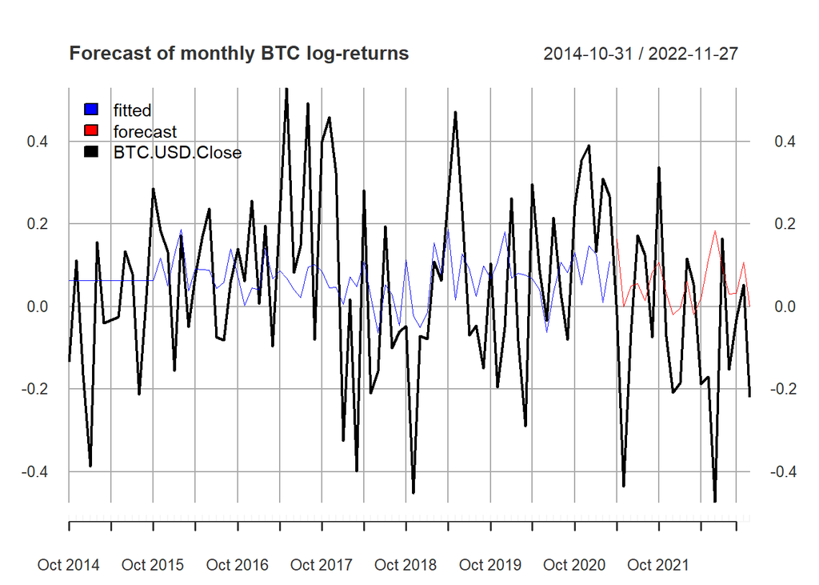

```r
forecast_log_returns <- xts(garch_fore@forecast$seriesFor[1, ], dates_out_of_sample)
forecast_volatility <- xts(garch_fore@forecast$sigmaFor[1, ], dates_out_of_sample)

# plot of log-returns
plot(cbind("fitted"   = fitted(garch_fit),
           "forecast" = forecast_log_returns,
           "original" = diff1_log_btc_monthly),
     col = c("blue", "red", "black"), lwd = c(0.5, 0.5, 2),
     main = "Forecast of monthly BTC log-returns", legend.loc = "topleft")
```

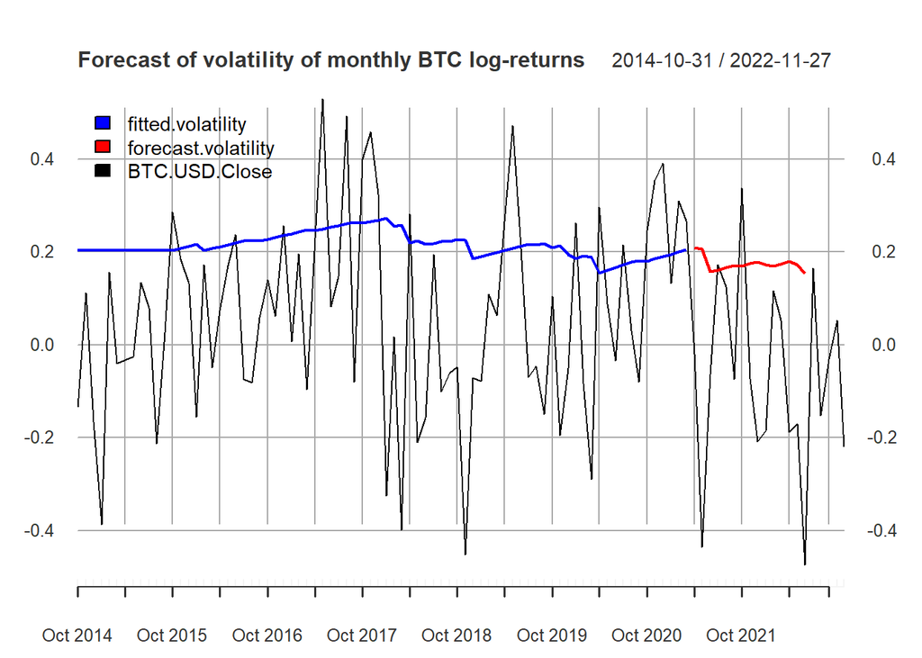

```r
# plot of volatility log-returns
plot(cbind("fitted volatility"   = sigma(garch_fit),
           "forecast volatility" = forecast_volatility,
           "log-returns"         = diff1_log_btc_monthly),
     col = c("blue", "red", "black"), lwd = c(2, 2, 1),
     main = "Forecast of volatility of monthly BTC log-returns", legend.loc = "topleft")
```

```r
# trainRow_Monthly=nrow(diff1_log_btc_monthly)-h
# train_monthlyR <- diff1_log_btc_monthly[1:trainRow_Monthly,]
# test_monthlyR <- diff1_log_btc_monthly[-c(1:trainRow_Monthly),]
#
#
# sfinal <- mM1
# coef(mM1)
#
# ugarchforecast(data=diff1_log_btc_monthly, fitORspec = mM1, n.ahead = h, n.roll = 1)
```

forecast error

```r
error_var <- rbind(
                   "gJRGARCH(1,1)" = c(var(diff1_log_btc_monthly - fitted(garch_fit)),
                                    var(diff1_log_btc_monthly - forecast_log_returns)))
colnames(error_var) <- c("in-sample", "out-of-sample")
print(error_var)
```

```
##                in-sample out-of-sample
## gJRGARCH(1,1) 0.04184756    0.04181831
```

show some plots of the out-of-sample error

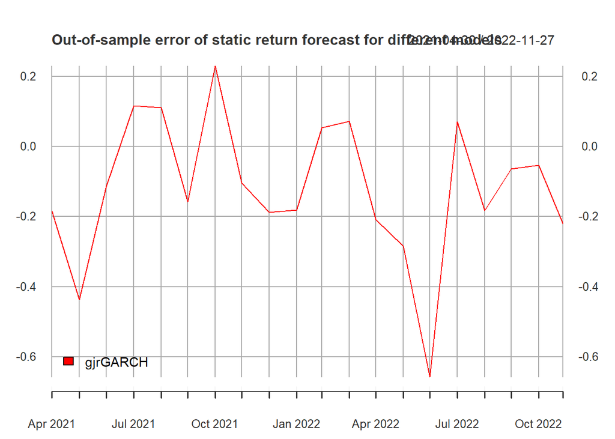

```r
error_logreturns <- cbind(diff1_log_btc_monthly - forecast_log_returns)
names(error_logreturns) <- c("gjrGARCH")
plot(error_logreturns, col = c("red"), lwd = c(1),
     main = "Out-of-sample error of static return forecast for different models", legend.loc = "bottomleft")
```

rolling window comparison

```r
# model specification of an gjrGARCH(1,1)
spec <- garch_spec

# static fit and forecast
static_fit <- ugarchfit(spec = spec, data = diff1_log_btc_monthly, out.sample = out_of_sample)
static_fore_logreturns <- xts(ugarchforecast(garch_fit, n.ahead = h, n.roll = out_of_sample-1)@forecast$seriesFor[1, ],
                                 dates_out_of_sample)
# rolling fit and forecast
modelroll <- ugarchroll(spec = spec, data = diff1_log_btc_monthly, n.ahead = 1,
                        forecast.length = out_of_sample, refit.every = 5, refit.window = "moving")
rolling_fore_logreturns <- xts(modelroll@forecast$density$Mu, dates_out_of_sample)

report(modelroll, type="VaR", VaR.alpha = 0.01, conf.level = 0.95)
```

```
## VaR Backtest Report
## ===========================================
## Model:               gjrGARCH-norm
## Backtest Length: 20
## Data:
##
## ==========================================
## alpha:               1%
## Expected Exceed: 0.2
## Actual VaR Exceed:   NA
## Actual %:            NA%
##
## Unconditional Coverage (Kupiec)
## Null-Hypothesis: Correct Exceedances
## LR.uc Statistic: NA
## LR.uc Critical:      3.841
## LR.uc p-value:       NA
## Reject Null:     NA
##
## Conditional Coverage (Christoffersen)
## Null-Hypothesis: Correct Exceedances and
##                  Independence of Failures
## LR.cc Statistic: NA
## LR.cc Critical:      5.991
## LR.cc p-value:       NA
## Reject Null:     NA
```

```r
report(modelroll, type="fpm")
```

```
##
## GARCH Roll Mean Forecast Performance Measures
## ---------------------------------------------
## Model        : gjrGARCH
## No.Refits    : 4
## No.Forecasts: 20
##
##       Stats
## MSE 0.05068
## MAE 0.17620
## DAC 0.45000
```

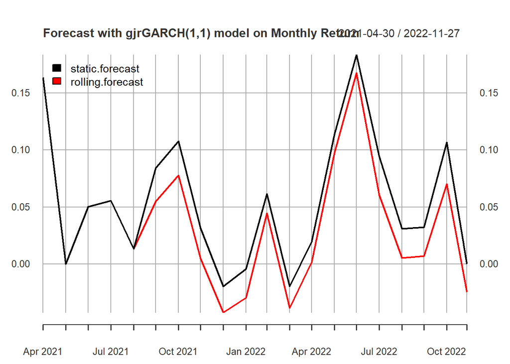

```r
# plot of forecast
plot(cbind("static forecast"  = static_fore_logreturns,
           "rolling forecast" = rolling_fore_logreturns),
     col = c("black", "red"), lwd = 2,
     main = "Forecast with gjrGARCH(1,1) model on Monthly Return", legend.loc = "topleft")
```

[figure not shown]

```r
# plot of forecast error
error_logreturns <- cbind(diff1_log_btc_monthly - static_fore_logreturns,
                          diff1_log_btc_monthly - rolling_fore_logreturns)
names(error_logreturns) <- c("rolling forecast", "static forecast")
plot(error_logreturns, col = c("black", "red"), lwd = 2,
     main = "Forecast error with gjrGARCH(1,1) model on Monthly Return", legend.loc = "topleft")
```

price forecast

```r
# simulate one path
# garch_spec <- ugarchspec(mean.model = list(armaOrder = c(0,0), include.mean = TRUE),
#                          variance.model = list(model = "eGARCH", garchOrder = c(1,1)),
#                          fixed.pars = as.list(coef(garch_fit))
#                                                )

garch_spec <- ugarchspec(variance.model=list(model="gjrGARCH",  garchOrder = c(1,1)),
                 mean.model=list(armaOrder=c(0,13),include.mean = TRUE),
                  fixed.pars = as.list(coef(garch_fit) ))

T <- 36
path_garch <- ugarchpath(garch_spec, m.sim = 3, n.sim = T, rseed=10)

str(path_garch@path$seriesSim)
```

```
##  num [1:36, 1:3] 0.0669 0.0255 -0.2232 -0.0524 0.1204 ...
```

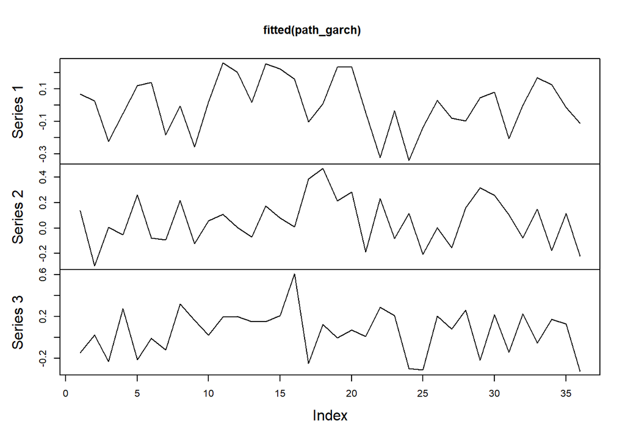

```r
plot.zoo(fitted(path_garch))
```

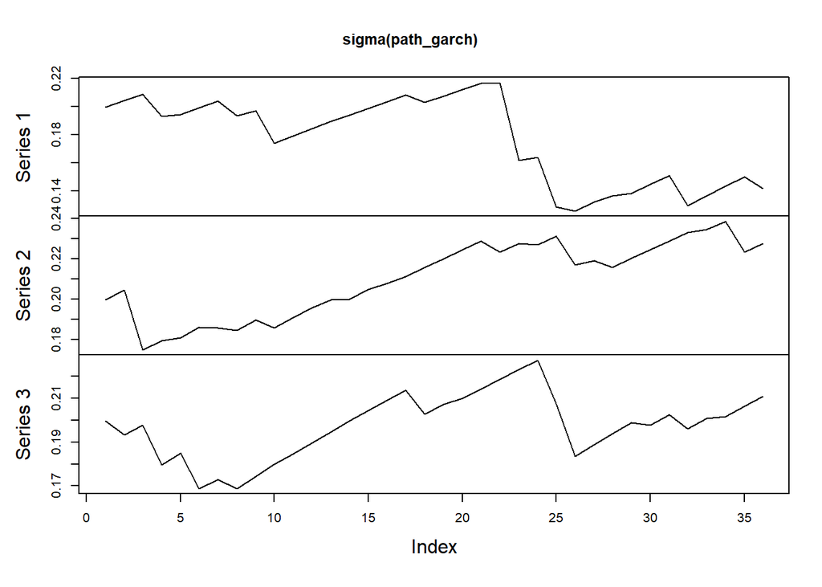

```r
plot.zoo(sigma(path_garch))
```

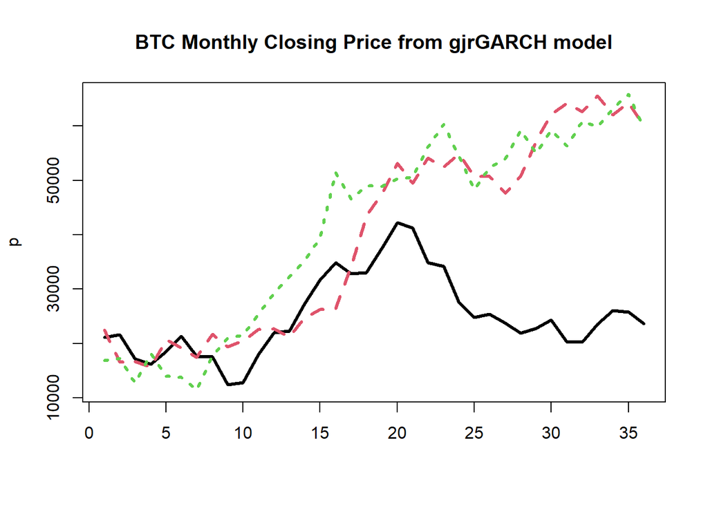

```r
fOrigin <- tail(index(train_monthlyR), 1)
fOriginPrice <- as.numeric(btc_monthly[fOrigin]$`BTC-USD.Close`)

p<-fOriginPrice*apply(fitted(path_garch),2,'cumsum') + fOriginPrice
matplot(p, type='l', lwd=3, main = "BTC Monthly Closing Price from gjrGARCH model")
```

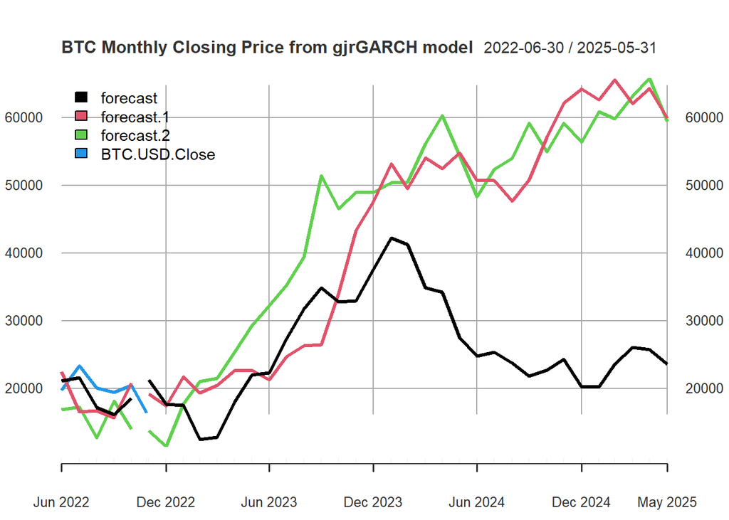

```r
d <- seq(as.Date(fOrigin+1),by='1 month',length=T) -1
p.xts <- xts(p, order.by=d)
plot(cbind("forecast"=p.xts,
           "actual"=window(btc_monthly,start=fOrigin)$`BTC-USD.Close`
           ),
     lwd=3, main = "BTC Monthly Closing Price from gjrGARCH model", legend.loc = "topleft")
```

## Compare with Other Methods - TBC

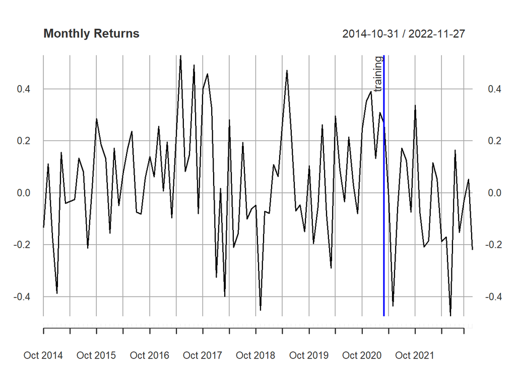

```r
T <- nrow(diff1_log_btc_monthly)
T_trn <- round(0.8*T)
T_tst <- T - T_trn

train_monthlyR <- diff1_log_btc_monthly[1:T_trn,]
test_monthlyR <- diff1_log_btc_monthly[-c(1:T_trn),]

# plot
{ plot(diff1_log_btc_monthly, main = "Monthly Returns", lwd = 1.5)
  addEventLines(xts("training", index(diff1_log_btc_monthly[T_trn])), srt=90, pos=2, lwd = 2, col = "blue") }
```

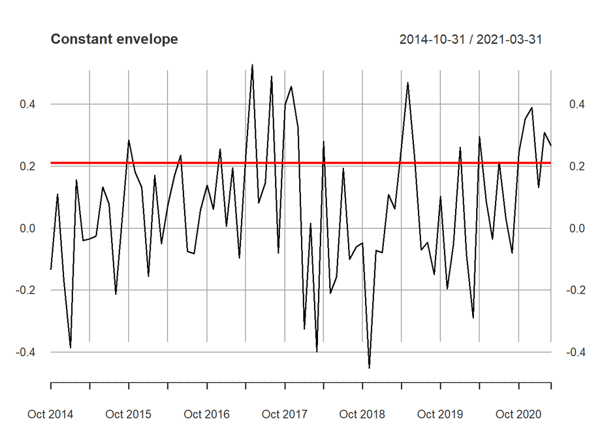

```r
var_constant <- var(train_monthlyR)  # or: mean(x_trn^2)
plot(cbind(sqrt(var_constant), train_monthlyR), col = c("red", "black"), lwd = c(2.5, 1.5),
     main = "Constant envelope")
```